# Empirical comparison of reliability coefficients using congeneric data: estimates for Allardt’s Life Satisfaction Scale and De Jong Gierveld 6-item Loneliness Scale

### Key reversion

```r
# DJGLS with negative questions reverse coded
reverse_col <- c("empty.G", "around.G", "reject.G")
DJGLS[, reverse_col] = 6 - DJGLS[, reverse_col]
```

```r
lonely_rev <- ALS$lonely.A
lonely_rev[lonely_rev == 4] <- -0 # the following line would convert 4 (CS) into 0, but as -0 it will stay as 4
lonely_rev = 4 - lonely_rev
ALS$lonely.A <- lonely_rev
```

Plotting the item response distributions with reversions

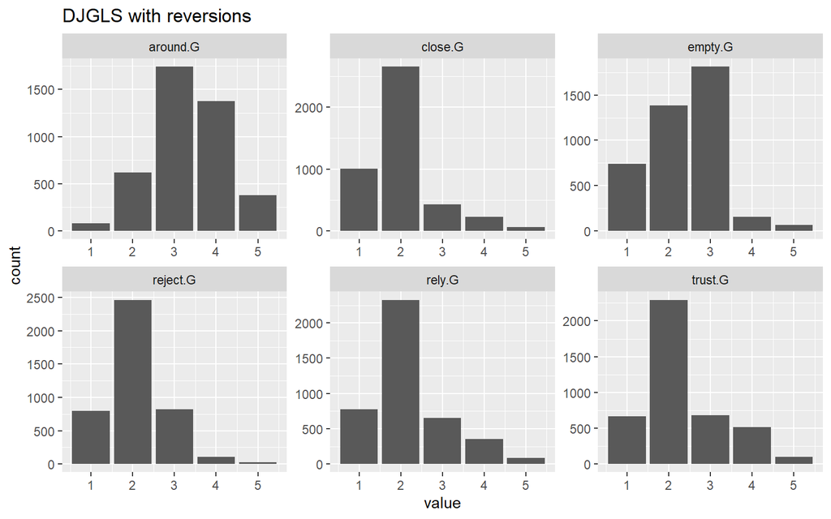

```r
# transforming the dataframes into long form
DJGLS.L <- DJGLS %>%
  pivot_longer(cols = all_of(Gierveld))

# plotting items of DJGLS with reversion
DJGLS.L[-1] %>%
  ggplot(aes(value)) +
  facet_wrap("name", scales = "free") +
  geom_bar() +
  ggtitle("DJGLS with reversions")
```

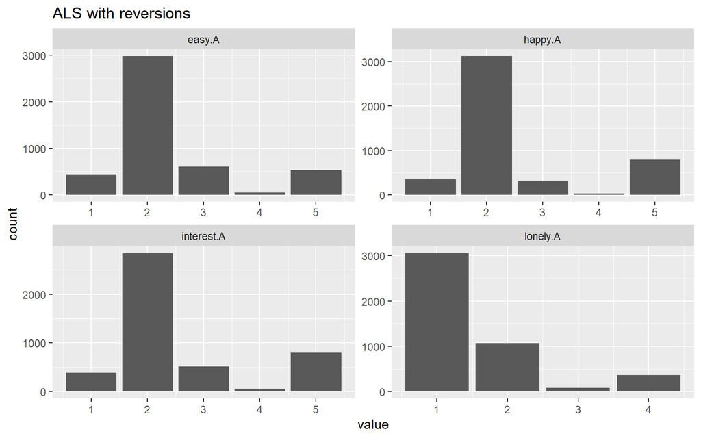

```r
# plotting items of A with reversion
ALS.L <- ALS %>%
  pivot_longer(cols = all_of(Allardt))
ALS.L %>%
  ggplot(aes(value)) +
  facet_wrap("name", scales = "free") +
  geom_bar() +
  ggtitle("ALS with reversions")
```

### Cannot Say -responses in ALS

The ALS scale has a Cannot Say -response option (CS) in all its items. These make up

```r
CS4 <- table(unlist(ALS[5]))[4] %>% as.vector
CS5 <- table(unlist(ALS[2:4]))[5] %>% as.vector
ALS_count <- sum(table(unlist(ALS[-1]))) %>% as.vector

# proportion of CS out of all responses
(CS4+CS5) / ALS_count
```

```
## [1] 0.1354597
```

```r
#############################table(unlist(is.na(ALS[-1])))[2] %>% as.vector
```

of the total responses. These can be interpreted as 1) neutral values or 2) missing values. We explored both.

#### CS as neutral values

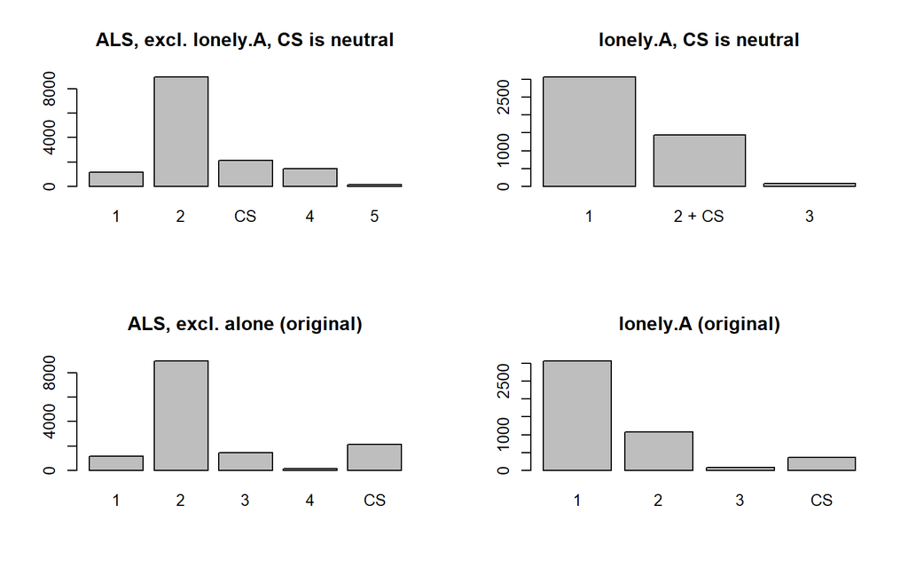

```r
CSNe <- ALS[1]

# moving CS of ALS (excl. lonely.A) to the middle
respread <- function(x){ifelse(x > 2, x + 1, x)}
CSis3 <- function(x){ifelse(x == 6, 3, x)}
CSNe[2:4] <- apply(ALS[2:4], 2, respread)
CSNe[2:4] <- apply(CSNe[2:4], 2, CSis3)

# converting CS of lonely.A
CSis2 <- function(x){ifelse(x == 4, 2, x)}
CSNe[5] <- apply(ALS[5], 2, CSis2)

# fixing the names
CSNe <- CSNe %>% rename(
  "interest.A" = "V1",
  "happy.A" = "V2",
  "easy.A" = "V3")
CSNe <- CSNe %>% rename("lonely.A" = "V1")

# comparison to originals (to check for errors)
par(mfrow = c(2,2))
barplot(table(unlist(CSNe[2:4])),
        main = "ALS, excl. lonely.A, CS is neutral",
        names.arg = c("1", "2", "CS", "4", "5"))
barplot(table(unlist(CSNe[5])),
        main = "lonely.A, CS is neutral",
        names.arg = c("1", "2 + CS","3"))
barplot(table(unlist(ALS[2:4])),
        main = "ALS, excl. alone (original)",
        names.arg = c("1", "2","3","4","CS"))
barplot(table(unlist(ALS[5])),
        main = "lonely.A (original)",
        names.arg = c("1", "2","3", "CS"))
```

Let’s see how the proportion of missing values looks like in ALS when the CS are interpreted as neutral:

```r
p <- function(x) {sum(is.na(x))/length(x)}
apply(CSNe,2,p)
```

```
##         ID interest.A    happy.A     easy.A   lonely.A
## 0.00000000 0.01286174 0.01200429 0.01350482 0.01650589
```

```r
# proportion of missing item-wise observations (entries) is the average of these
apply(CSNe,2,p) %>% sum()/4
```

```
## [1] 0.01371919
```

#### CS as missing values

```r
library(naniar)
# coding CS responses as missing values
CSNA <- ALS %>%
  replace_with_na_at(.vars = c("interest.A","happy.A", "easy.A"),
                     condition = ~.x == 5) %>%
  replace_with_na(replace = list(lonely.A = 4))
```

Let’s see how the proportion of missing values looks like in ALS when the CS are interpreted as missing values:

```r
apply(CSNA,2,p)
```

```
##         ID interest.A    happy.A     easy.A   lonely.A
## 0.00000000 0.18456592 0.18135048 0.12775991 0.09560557
```

```r
# proportion of missing item-wise observations (entries) is the average of these
apply(CSNA,2,p) %>% sum()/4
```

```
## [1] 0.1473205
```

### Missing values

Proportion of missing values:

```r
apply(CSNA,2,p)
```

```
##         ID interest.A    happy.A     easy.A   lonely.A
## 0.00000000 0.18456592 0.18135048 0.12775991 0.09560557
```

```r
apply(CSNe,2,p)
```

```
##         ID interest.A    happy.A     easy.A   lonely.A
## 0.00000000 0.01286174 0.01200429 0.01350482 0.01650589
```

```r
apply(DJGLS,2,p)
```

```
##         ID     rely.G    trust.G    close.G    empty.G   around.G   reject.G
## 0.00000000 0.09989282 0.08595927 0.06302251 0.10868167 0.10075027 0.09646302
```

#### Removing rows with multiple missing values

```r
# saving datasets without row removal for later use
DJGLS. <- DJGLS

# removing rows with more than one missing value
DJGLS <- DJGLS[!rowSums(is.na(DJGLS)) > 1,]
CSNA <- CSNA[!rowSums(is.na(CSNA)) > 1,]
CSNe <- CSNe[!rowSums(is.na(CSNe)) > 1,]
```

#### Imputations

```r
# function version would look like this, although it's now included in the relisens, making it inefficient computing-wise but a lot easier to use. Should we just mention here which imputation methods will be used and delete these? I think these are only used in the correlation thingies in the following section and under Item variations->Correlations.

library(mice)
library(haven)
# Mean imputation
  mean_imp <- function(data){
    data %>%
    mutate_all(~ifelse(is.na(.x), mean(.x, na.rm = TRUE), .x))
    }
# deterministic
  det_imp <- function(data){
    data %>%
    zap_labels %>%
    mice(method = "norm.predict", m=1) %>%
    complete
    }
# stochastic linear regression imputation
  sto_imp <- function(data){
    data %>%
    zap_labels %>%
    mice(method = "norm.nob", m = 1) %>%
    complete
  }
```

```r
# applying
# CSNA
CSNA_mean <- CSNA[1]
CSNA_mean[2:5] <- mean_imp(CSNA[-1])

CSNA_det <- CSNA[1]
CSNA_det[2:5] <- det_imp(CSNA[-1])
CSNA_sto <- CSNA[1]
CSNA_sto[2:5] <- sto_imp(CSNA[-1])
# CSNe
CSNe_mean <- CSNe[1]
CSNe_mean[2:5] <- mean_imp(CSNe[-1])

CSNe_det <- CSNe[1]
CSNe_det[2:5] <- det_imp(CSNe[-1])
CSNe_sto <- CSNe[1]
CSNe_sto[2:5] <- sto_imp(CSNe[-1])
# DJGLS
DJGLS_mean <- DJGLS[1]
DJGLS_mean[2:7] <- DJGLS[-1] %>% mean_imp

DJGLS_det <- DJGLS[1]
DJGLS_det[2:7] <- DJGLS[-1] %>% det_imp
DJGLS_sto <- DJGLS[1]
DJGLS_sto[2:7] <- DJGLS[-1] %>% sto_imp
```

Descriptive statistics of CSNe_det & DJGLS_det

```r
library(e1071)

apply(DJGLS_det[-1], 2, mean) %>% round(3)
```

```
##   rely.G  trust.G  close.G  empty.G around.G reject.G
##    2.215    2.339    2.034    2.367    3.315    2.071
```

```r
apply(DJGLS_det[-1], 2, sd) %>% round(3)
```

```
##   rely.G  trust.G  close.G  empty.G around.G reject.G
##    0.902    0.953    0.811    0.854    0.889    0.729
```

```r
lapply(DJGLS_det[-1], na.rm=TRUE, skewness, type=2) %>% as.data.frame %>% round(3)
```

```
##   rely.G trust.G close.G empty.G around.G reject.G
## 1   0.93   0.805   1.179   0.047   -0.098    0.645
```

```r
lapply(DJGLS_det[-1], na.rm=TRUE, kurtosis, type=2) %>% as.data.frame %>% round(3)
```

```
##   rely.G trust.G close.G empty.G around.G reject.G
## 1  0.845   0.218   2.184  -0.054   -0.203    1.178
```

```r
apply(CSNe_det[-1], 2, mean) %>% round(3)
```

```
## interest.A    happy.A     easy.A   lonely.A
##      2.352      2.257      2.313      1.352
```

```r
apply(CSNe_det[-1], 2, sd) %>% round(3)
```

```
## interest.A    happy.A     easy.A   lonely.A
##      0.833      0.720      0.851      0.513
```

```r
lapply(CSNe_det[-1], na.rm=TRUE, skewness, type=2) %>% as.data.frame %>% round(3)
```

```
##   interest.A happy.A easy.A lonely.A
## 1      0.945   1.104  1.008    1.025
```

```r
lapply(CSNe_det[-1], na.rm=TRUE, kurtosis, type=2) %>% as.data.frame %>% round(3)
```

```
##   interest.A happy.A easy.A lonely.A
## 1      0.663   1.641  0.591   -0.098
```

```r
apply(CSNA_det[-1], 2, mean) %>% round(3)
```

```
## interest.A    happy.A     easy.A   lonely.A
##      2.054      2.018      2.054      1.257
```

```r
apply(CSNA_det[-1], 2, sd) %>% round(3)
```

```
## interest.A    happy.A     easy.A   lonely.A
##      0.526      0.455      0.539      0.464
```

```r
lapply(CSNA_det[-1], na.rm=TRUE, skewness, type=2) %>% as.data.frame %>% round(3)
```

```
##   interest.A happy.A easy.A lonely.A
## 1       0.61   0.475  0.438    1.601
```

```r
lapply(CSNA_det[-1], na.rm=TRUE, kurtosis, type=2) %>% as.data.frame %>% round(3)
```

```
##   interest.A happy.A easy.A lonely.A
## 1      2.473   3.717  1.772    1.665
```

```r
save.image(file = "wrangled-data.RData")
```

# Reliability Analysis

Load data:

```r
load("wrangled-data.RData")
library(tidyverse)
library(psych)
```

```r
# to see the results without the around.G reversed, run this before the rest
DJGLS[, "around.G"] = 6 - DJGLS[, "around.G"]
DJGLS.[, "around.G"] = 6 - DJGLS.[, "around.G"]
```

## Testing the assumptions of the tau-equivalent model

### Unidimensionality & Tau-equivalence

#### DJGLS

Making a scree plot:

```r
# pca
results <- prcomp(DJGLS_det[-1])
results$rotation %>% as.data.frame
```

```
##                 PC1         PC2        PC3         PC4          PC5
## rely.G    0.5391909  0.04321208  0.2354613 -0.08474888 -0.518251945
## trust.G   0.5776585  0.12993308  0.2710109  0.31542091  0.690258661
## close.G   0.4542516  0.03837269  0.1448661 -0.18094797 -0.354977554
## empty.G   0.2771708 -0.57507602 -0.5647647  0.50509893 -0.132536275
## around.G -0.1971255 -0.69652551  0.6846530  0.07667621 -0.007461721
## reject.G  0.2314241 -0.40486719 -0.2498318 -0.77432612  0.333657454
##                   PC6
## rely.G   -0.613348509
## trust.G  -0.005810692
## close.G   0.782589032
## empty.G   0.028528914
## around.G  0.036180884
## reject.G -0.095923375
```

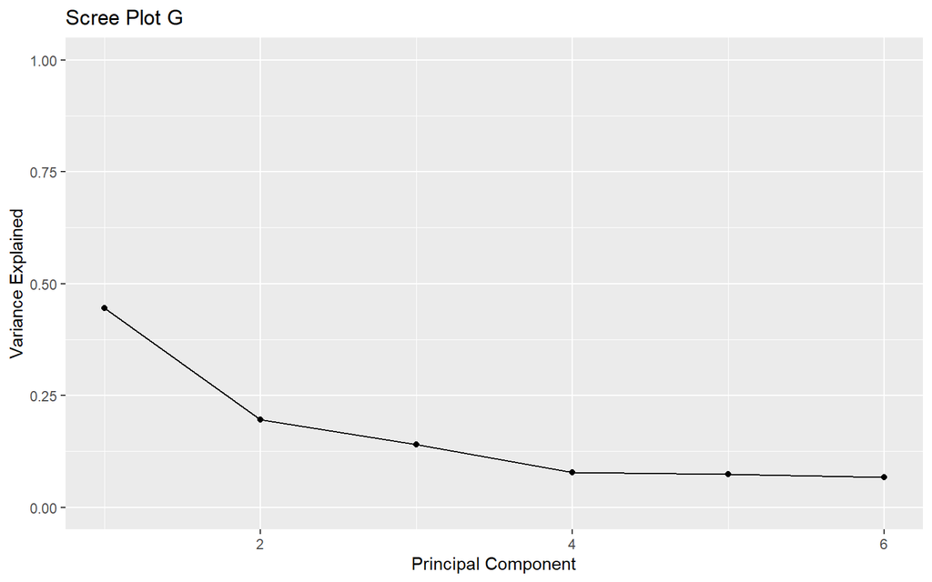

```r
# calculate total variance explained by each principal component
var_explained = results$sdev^2 / sum(results$sdev^2)

#create scree plot
qplot(c(1:6),var_explained) +
  geom_line() +
  xlab("Principal Component") +
  ylab("Variance Explained") +
  ggtitle("Scree Plot G") +
  ylim(0, 1)
```

```r
library(psych)
fa(DJGLS_det[-1], nfactors = 2, rotate = "oblimin")
```

```
## Factor Analysis using method =  minres
## Call: fa(r = DJGLS_det[-1], nfactors = 2, rotate = "oblimin")
## Standardized loadings (pattern matrix) based upon correlation matrix
##            MR1   MR2   h2   u2 com
## rely.G    0.77  0.03 0.62 0.38 1.0
## trust.G   0.81 -0.04 0.63 0.37 1.0
## close.G   0.72  0.05 0.55 0.45 1.0
## empty.G   0.05  0.57 0.35 0.65 1.0
## around.G -0.35  0.21 0.10 0.90 1.7
## reject.G  0.00  0.73 0.53 0.47 1.0
##
##                        MR1  MR2
## SS loadings           1.88 0.89
## Proportion Var        0.31 0.15
## Cumulative Var        0.31 0.46
## Proportion Explained  0.68 0.32
## Cumulative Proportion 0.68 1.00
##
##  With factor correlations of
##      MR1  MR2
## MR1 1.00 0.45
## MR2 0.45 1.00
##
## Mean item complexity =  1.1
## Test of the hypothesis that 2 factors are sufficient.
##
## df null model =  15  with the objective function =  1.43 with Chi Square =  5923.73
## df of  the model are 4  and the objective function was  0
##
## The root mean square of the residuals (RMSR) is  0.01
## The df corrected root mean square of the residuals is  0.01
##
## The harmonic n.obs is  4142 with the empirical chi square  3.17  with prob <  0.53
## The total n.obs was  4142  with Likelihood Chi Square =  5.54  with prob <  0.24
##
## Tucker Lewis Index of factoring reliability =  0.999
## RMSEA index =  0.01  and the 90 % confidence intervals are  0 0.027
## BIC =  -27.78
## Fit based upon off diagonal values = 1
## Measures of factor score adequacy
##                                                    MR1  MR2
## Correlation of (regression) scores with factors   0.91 0.81
## Multiple R square of scores with factors          0.83 0.65
## Minimum correlation of possible factor scores     0.65 0.31
```

```r
fa(DJGLS_det[-1], nfactors = 2, rotate = "varimax")
```

```
## Factor Analysis using method =  minres
## Call: fa(r = DJGLS_det[-1], nfactors = 2, rotate = "varimax")
## Standardized loadings (pattern matrix) based upon correlation matrix
##            MR1  MR2   h2   u2 com
## rely.G    0.73 0.29 0.62 0.38 1.3
## trust.G   0.76 0.23 0.63 0.37 1.2
## close.G   0.68 0.28 0.55 0.45 1.3
## empty.G   0.12 0.58 0.35 0.65 1.1
## around.G -0.30 0.09 0.10 0.90 1.2
## reject.G  0.09 0.72 0.53 0.47 1.0
##
##                        MR1  MR2
## SS loadings           1.69 1.08
## Proportion Var        0.28 0.18
## Cumulative Var        0.28 0.46
## Proportion Explained  0.61 0.39
## Cumulative Proportion 0.61 1.00
##
## Mean item complexity =  1.2
## Test of the hypothesis that 2 factors are sufficient.
##
## df null model =  15  with the objective function =  1.43 with Chi Square =  5923.73
## df of  the model are 4  and the objective function was  0
##
## The root mean square of the residuals (RMSR) is  0.01
## The df corrected root mean square of the residuals is  0.01
##
## The harmonic n.obs is  4142 with the empirical chi square  3.17  with prob <  0.53
## The total n.obs was  4142  with Likelihood Chi Square =  5.54  with prob <  0.24
##
## Tucker Lewis Index of factoring reliability =  0.999
## RMSEA index =  0.01  and the 90 % confidence intervals are  0 0.027
## BIC =  -27.78
## Fit based upon off diagonal values = 1
## Measures of factor score adequacy
##                                                    MR1  MR2
## Correlation of (regression) scores with factors   0.87 0.79
## Multiple R square of scores with factors          0.76 0.62
## Minimum correlation of possible factor scores     0.53 0.24
```

```r
fa(DJGLS_det[-1], nfactors = 1, rotate = "oblimin")
```

```
## Factor Analysis using method =  minres
## Call: fa(r = DJGLS_det[-1], nfactors = 1, rotate = "oblimin")
## Standardized loadings (pattern matrix) based upon correlation matrix
##            MR1    h2   u2 com
## rely.G    0.78 0.614 0.39   1
## trust.G   0.76 0.579 0.42   1
## close.G   0.74 0.552 0.45   1
## empty.G   0.37 0.134 0.87   1
## around.G -0.21 0.043 0.96   1
## reject.G  0.39 0.150 0.85   1
##
##                 MR1
## SS loadings    2.07
## Proportion Var 0.35
##
## Mean item complexity =  1
## Test of the hypothesis that 1 factor is sufficient.
##
## df null model =  15  with the objective function =  1.43 with Chi Square =  5923.73
## df of  the model are 9  and the objective function was  0.17
##
## The root mean square of the residuals (RMSR) is  0.09
## The df corrected root mean square of the residuals is  0.12
##
## The harmonic n.obs is  4142 with the empirical chi square  995.95  with prob <  1.3e-208
## The total n.obs was  4142  with Likelihood Chi Square =  689.29  with prob <  1.4e-142
##
## Tucker Lewis Index of factoring reliability =  0.808
## RMSEA index =  0.135  and the 90 % confidence intervals are  0.127 0.144
## BIC =  614.33
## Fit based upon off diagonal values = 0.93
## Measures of factor score adequacy
##                                                    MR1
## Correlation of (regression) scores with factors   0.91
## Multiple R square of scores with factors          0.82
## Minimum correlation of possible factor scores     0.64
```

```r
fa(DJGLS_det[-1], nfactors = 3, rotate = "oblimin")
```

```
## Factor Analysis using method =  minres
## Call: fa(r = DJGLS_det[-1], nfactors = 3, rotate = "oblimin")
## Standardized loadings (pattern matrix) based upon correlation matrix
##            MR1   MR2   MR3   h2    u2 com
## rely.G    0.79  0.02  0.01 0.63 0.370   1
## trust.G   0.80 -0.01 -0.04 0.62 0.382   1
## close.G   0.71 -0.01  0.04 0.54 0.457   1
## empty.G   0.01 -0.01  0.60 0.37 0.630   1
## around.G  0.00  1.00  0.00 1.00 0.005   1
## reject.G -0.01  0.00  0.71 0.50 0.504   1
##
##                        MR1  MR2  MR3
## SS loadings           1.79 1.00 0.87
## Proportion Var        0.30 0.17 0.15
## Cumulative Var        0.30 0.46 0.61
## Proportion Explained  0.49 0.27 0.24
## Cumulative Proportion 0.49 0.76 1.00
##
##  With factor correlations of
##       MR1   MR2  MR3
## MR1  1.00 -0.25 0.48
## MR2 -0.25  1.00 0.05
## MR3  0.48  0.05 1.00
##
## Mean item complexity =  1
## Test of the hypothesis that 3 factors are sufficient.
##
## df null model =  15  with the objective function =  1.43 with Chi Square =  5923.73
## df of  the model are 0  and the objective function was  0
##
## The root mean square of the residuals (RMSR) is  0
## The df corrected root mean square of the residuals is  NA
##
## The harmonic n.obs is  4142 with the empirical chi square  0.02  with prob <  NA
## The total n.obs was  4142  with Likelihood Chi Square =  0.05  with prob <  NA
##
## Tucker Lewis Index of factoring reliability =  -Inf
## Fit based upon off diagonal values = 1
## Measures of factor score adequacy
##                                                    MR1  MR2  MR3
## Correlation of (regression) scores with factors   0.91 1.00 0.81
## Multiple R square of scores with factors          0.83 1.00 0.65
## Minimum correlation of possible factor scores     0.65 0.99 0.30
```

```r
library(psych)
fa(DJGLS_mean[-1], nfactors = 2)
```

```
## Factor Analysis using method =  minres
## Call: fa(r = DJGLS_mean[-1], nfactors = 2)
## Standardized loadings (pattern matrix) based upon correlation matrix
##            MR1   MR2    h2   u2 com
## rely.G    0.76  0.03 0.597 0.40 1.0
## trust.G   0.80 -0.03 0.614 0.39 1.0
## close.G   0.71  0.04 0.537 0.46 1.0
## empty.G   0.05  0.54 0.323 0.68 1.0
## around.G -0.35  0.21 0.099 0.90 1.6
## reject.G  0.00  0.73 0.530 0.47 1.0
##
##                        MR1  MR2
## SS loadings           1.83 0.87
## Proportion Var        0.31 0.14
## Cumulative Var        0.31 0.45
## Proportion Explained  0.68 0.32
## Cumulative Proportion 0.68 1.00
##
##  With factor correlations of
##      MR1  MR2
## MR1 1.00 0.45
## MR2 0.45 1.00
##
## Mean item complexity =  1.1
## Test of the hypothesis that 2 factors are sufficient.
##
## df null model =  15  with the objective function =  1.35 with Chi Square =  5590.77
## df of  the model are 4  and the objective function was  0
##
## The root mean square of the residuals (RMSR) is  0
## The df corrected root mean square of the residuals is  0.01
##
## The harmonic n.obs is  4142 with the empirical chi square  2.76  with prob <  0.6
## The total n.obs was  4142  with Likelihood Chi Square =  4.49  with prob <  0.34
##
## Tucker Lewis Index of factoring reliability =  1
## RMSEA index =  0.005  and the 90 % confidence intervals are  0 0.025
## BIC =  -28.82
## Fit based upon off diagonal values = 1
## Measures of factor score adequacy
##                                                    MR1  MR2
## Correlation of (regression) scores with factors   0.90 0.80
## Multiple R square of scores with factors          0.82 0.65
## Minimum correlation of possible factor scores     0.63 0.29
```

```r
fa(DJGLS_det[-1], nfactors = 2)
```

```
## Factor Analysis using method =  minres
## Call: fa(r = DJGLS_det[-1], nfactors = 2)
## Standardized loadings (pattern matrix) based upon correlation matrix
##            MR1   MR2   h2   u2 com
## rely.G    0.77  0.03 0.62 0.38 1.0
## trust.G   0.81 -0.04 0.63 0.37 1.0
## close.G   0.72  0.05 0.55 0.45 1.0
## empty.G   0.05  0.57 0.35 0.65 1.0
## around.G -0.35  0.21 0.10 0.90 1.7
## reject.G  0.00  0.73 0.53 0.47 1.0
##
##                        MR1  MR2
## SS loadings           1.88 0.89
## Proportion Var        0.31 0.15
## Cumulative Var        0.31 0.46
## Proportion Explained  0.68 0.32
## Cumulative Proportion 0.68 1.00
##
##  With factor correlations of
##      MR1  MR2
## MR1 1.00 0.45
## MR2 0.45 1.00
##
## Mean item complexity =  1.1
## Test of the hypothesis that 2 factors are sufficient.
##
## df null model =  15  with the objective function =  1.43 with Chi Square =  5923.73
## df of  the model are 4  and the objective function was  0
##
## The root mean square of the residuals (RMSR) is  0.01
## The df corrected root mean square of the residuals is  0.01
##
## The harmonic n.obs is  4142 with the empirical chi square  3.17  with prob <  0.53
## The total n.obs was  4142  with Likelihood Chi Square =  5.54  with prob <  0.24
##
## Tucker Lewis Index of factoring reliability =  0.999
## RMSEA index =  0.01  and the 90 % confidence intervals are  0 0.027
## BIC =  -27.78
## Fit based upon off diagonal values = 1
## Measures of factor score adequacy
##                                                    MR1  MR2
## Correlation of (regression) scores with factors   0.91 0.81
## Multiple R square of scores with factors          0.83 0.65
## Minimum correlation of possible factor scores     0.65 0.31
```

```r
fa(DJGLS_sto[-1], nfactors = 2)
```

```
## Factor Analysis using method =  minres
## Call: fa(r = DJGLS_sto[-1], nfactors = 2)
## Standardized loadings (pattern matrix) based upon correlation matrix
##            MR1   MR2    h2   u2 com
## rely.G    0.76  0.04 0.610 0.39 1.0
## trust.G   0.81 -0.04 0.625 0.38 1.0
## close.G   0.71  0.05 0.541 0.46 1.0
## empty.G   0.05  0.56 0.345 0.66 1.0
## around.G -0.35  0.21 0.099 0.90 1.6
## reject.G  0.00  0.73 0.527 0.47 1.0
##
##                        MR1  MR2
## SS loadings           1.86 0.89
## Proportion Var        0.31 0.15
## Cumulative Var        0.31 0.46
## Proportion Explained  0.68 0.32
## Cumulative Proportion 0.68 1.00
##
##  With factor correlations of
##      MR1  MR2
## MR1 1.00 0.45
## MR2 0.45 1.00
##
## Mean item complexity =  1.1
## Test of the hypothesis that 2 factors are sufficient.
##
## df null model =  15  with the objective function =  1.41 with Chi Square =  5819.39
## df of  the model are 4  and the objective function was  0
##
## The root mean square of the residuals (RMSR) is  0.01
## The df corrected root mean square of the residuals is  0.01
##
## The harmonic n.obs is  4142 with the empirical chi square  3.15  with prob <  0.53
## The total n.obs was  4142  with Likelihood Chi Square =  5.34  with prob <  0.25
##
## Tucker Lewis Index of factoring reliability =  0.999
## RMSEA index =  0.009  and the 90 % confidence intervals are  0 0.027
## BIC =  -27.98
## Fit based upon off diagonal values = 1
## Measures of factor score adequacy
##                                                    MR1  MR2
## Correlation of (regression) scores with factors   0.91 0.81
## Multiple R square of scores with factors          0.82 0.65
## Minimum correlation of possible factor scores     0.64 0.30
```

The imputation method has a negligible influence on the factor analysis results with two factors.

```r
fa(DJGLS_det[-1], nfactors = 1)
```

```
## Factor Analysis using method =  minres
## Call: fa(r = DJGLS_det[-1], nfactors = 1)
## Standardized loadings (pattern matrix) based upon correlation matrix
##            MR1    h2   u2 com
## rely.G    0.78 0.614 0.39   1
## trust.G   0.76 0.579 0.42   1
## close.G   0.74 0.552 0.45   1
## empty.G   0.37 0.134 0.87   1
## around.G -0.21 0.043 0.96   1
## reject.G  0.39 0.150 0.85   1
##
##                 MR1
## SS loadings    2.07
## Proportion Var 0.35
##
## Mean item complexity =  1
## Test of the hypothesis that 1 factor is sufficient.
##
## df null model =  15  with the objective function =  1.43 with Chi Square =  5923.73
## df of  the model are 9  and the objective function was  0.17
##
## The root mean square of the residuals (RMSR) is  0.09
## The df corrected root mean square of the residuals is  0.12
##
## The harmonic n.obs is  4142 with the empirical chi square  995.95  with prob <  1.3e-208
## The total n.obs was  4142  with Likelihood Chi Square =  689.29  with prob <  1.4e-142
##
## Tucker Lewis Index of factoring reliability =  0.808
## RMSEA index =  0.135  and the 90 % confidence intervals are  0.127 0.144
## BIC =  614.33
## Fit based upon off diagonal values = 0.93
## Measures of factor score adequacy
##                                                    MR1
## Correlation of (regression) scores with factors   0.91
## Multiple R square of scores with factors          0.82
## Minimum correlation of possible factor scores     0.64
```

```r
fa(DJGLS_det[-1], nfactors = 3)
```

```
## Factor Analysis using method =  minres
## Call: fa(r = DJGLS_det[-1], nfactors = 3)
## Standardized loadings (pattern matrix) based upon correlation matrix
##            MR1   MR2   MR3   h2    u2 com
## rely.G    0.79  0.02  0.01 0.63 0.370   1
## trust.G   0.80 -0.01 -0.04 0.62 0.382   1
## close.G   0.71 -0.01  0.04 0.54 0.457   1
## empty.G   0.01 -0.01  0.60 0.37 0.630   1
## around.G  0.00  1.00  0.00 1.00 0.005   1
## reject.G -0.01  0.00  0.71 0.50 0.504   1
##
##                        MR1  MR2  MR3
## SS loadings           1.79 1.00 0.87
## Proportion Var        0.30 0.17 0.15
## Cumulative Var        0.30 0.46 0.61
## Proportion Explained  0.49 0.27 0.24
## Cumulative Proportion 0.49 0.76 1.00
##
##  With factor correlations of
##       MR1   MR2  MR3
## MR1  1.00 -0.25 0.48
## MR2 -0.25  1.00 0.05
## MR3  0.48  0.05 1.00
##
## Mean item complexity =  1
## Test of the hypothesis that 3 factors are sufficient.
##
## df null model =  15  with the objective function =  1.43 with Chi Square =  5923.73
## df of  the model are 0  and the objective function was  0
##
## The root mean square of the residuals (RMSR) is  0
## The df corrected root mean square of the residuals is  NA
##
## The harmonic n.obs is  4142 with the empirical chi square  0.02  with prob <  NA
## The total n.obs was  4142  with Likelihood Chi Square =  0.05  with prob <  NA
##
## Tucker Lewis Index of factoring reliability =  -Inf
## Fit based upon off diagonal values = 1
## Measures of factor score adequacy
##                                                    MR1  MR2  MR3
## Correlation of (regression) scores with factors   0.91 1.00 0.81
## Multiple R square of scores with factors          0.83 1.00 0.65
## Minimum correlation of possible factor scores     0.65 0.99 0.30
```

One factor is evidently too little: the communalities in the emotional loneliness factor are all very low.

#### ALS

```r
# In the 6-item G validation study they used pca, so checking how that works for this data
r <- CSNe_det %>%
  select(-ID) %>%
  cor(use = "complete.obs")

# with scree plot
results <- prcomp(CSNe_det[-1])
results$rotation %>% as.data.frame
```

```
##                  PC1        PC2         PC3         PC4
## interest.A 0.6074287  0.4745399 -0.29671873  0.56373779
## happy.A    0.5132083  0.2412133 -0.11356506 -0.81580414
## easy.A     0.5588600 -0.8221666  0.02789991  0.10459073
## lonely.A   0.2352090  0.2016682  0.94777770  0.07565766
```

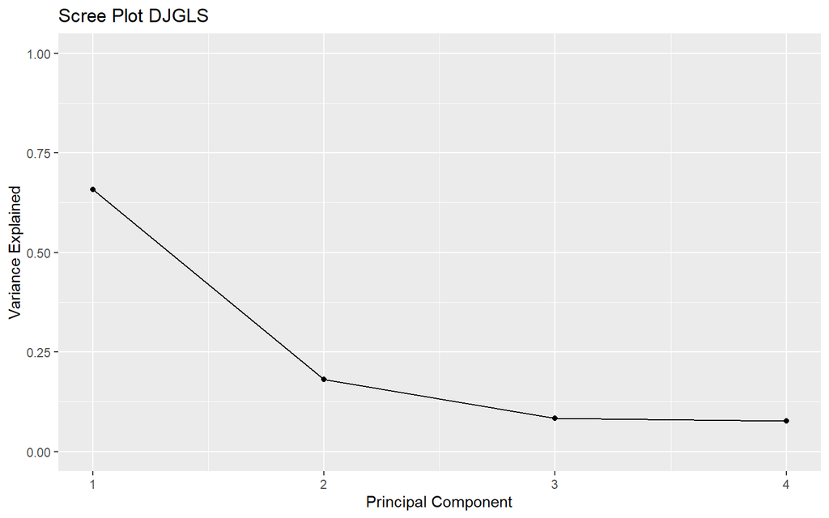

```r
# scree plot
#calculate total variance explained by each principal component
var_explained = results$sdev^2 / sum(results$sdev^2)

#create scree plot
qplot(c(1:4),var_explained) +
  geom_line() +
  xlab("Principal Component") +
  ylab("Variance Explained") +
  ggtitle("Scree Plot DJGLS") +
  ylim(0, 1)
```

```r
library(psych)
# allardt, CSNA vs CSNe
fa(CSNA[-1], nfactors = 1)
```

```
## Factor Analysis using method =  minres
## Call: fa(r = CSNA[-1], nfactors = 1)
## Standardized loadings (pattern matrix) based upon correlation matrix
##             MR1   h2   u2 com
## interest.A 0.84 0.71 0.29   1
## happy.A    0.82 0.68 0.32   1
## easy.A     0.58 0.33 0.67   1
## lonely.A   0.51 0.26 0.74   1
##
##                 MR1
## SS loadings    1.97
## Proportion Var 0.49
##
## Mean item complexity =  1
## Test of the hypothesis that 1 factor is sufficient.
##
## df null model =  6  with the objective function =  1.22 with Chi Square =  4707.59
## df of  the model are 2  and the objective function was  0.01
##
## The root mean square of the residuals (RMSR) is  0.02
## The df corrected root mean square of the residuals is  0.03
##
## The harmonic n.obs is  3571 with the empirical chi square  15.33  with prob <  0.00047
## The total n.obs was  3872  with Likelihood Chi Square =  37.32  with prob <  7.9e-09
##
## Tucker Lewis Index of factoring reliability =  0.977
## RMSEA index =  0.068  and the 90 % confidence intervals are  0.05 0.087
## BIC =  20.8
## Fit based upon off diagonal values = 1
## Measures of factor score adequacy
##                                                    MR1
## Correlation of (regression) scores with factors   0.92
## Multiple R square of scores with factors          0.84
## Minimum correlation of possible factor scores     0.68
```

```r
#fa(A[-1], nfactors = 2)
#fa(A[-1], nfactors = 3)

fa(CSNe[-1], nfactors = 1)
```

```
## Factor Analysis using method =  minres
## Call: fa(r = CSNe[-1], nfactors = 1)
## Standardized loadings (pattern matrix) based upon correlation matrix
##             MR1   h2   u2 com
## interest.A 0.84 0.71 0.29   1
## happy.A    0.85 0.73 0.27   1
## easy.A     0.59 0.35 0.65   1
## lonely.A   0.53 0.28 0.72   1
##
##                 MR1
## SS loadings    2.07
## Proportion Var 0.52
##
## Mean item complexity =  1
## Test of the hypothesis that 1 factor is sufficient.
##
## df null model =  6  with the objective function =  1.34 with Chi Square =  6185.91
## df of  the model are 2  and the objective function was  0.01
##
## The root mean square of the residuals (RMSR) is  0.02
## The df corrected root mean square of the residuals is  0.03
##
## The harmonic n.obs is  4561 with the empirical chi square  13.22  with prob <  0.0013
## The total n.obs was  4616  with Likelihood Chi Square =  30.04  with prob <  3e-07
##
## Tucker Lewis Index of factoring reliability =  0.986
## RMSEA index =  0.055  and the 90 % confidence intervals are  0.039 0.073
## BIC =  13.16
## Fit based upon off diagonal values = 1
## Measures of factor score adequacy
##                                                    MR1
## Correlation of (regression) scores with factors   0.93
## Multiple R square of scores with factors          0.86
## Minimum correlation of possible factor scores     0.72
```

```r
#fa(CSNe[2:5], nfactors = 2)
#fa(CSNe[2:5], nfactors = 3)

fa(CSNe_det[-1], 1) # imputation makes negligible difference
```

```
## Factor Analysis using method =  minres
## Call: fa(r = CSNe_det[-1], nfactors = 1)
## Standardized loadings (pattern matrix) based upon correlation matrix
##             MR1   h2   u2 com
## interest.A 0.84 0.71 0.29   1
## happy.A    0.86 0.73 0.27   1
## easy.A     0.59 0.35 0.65   1
## lonely.A   0.53 0.28 0.72   1
##
##                 MR1
## SS loadings    2.07
## Proportion Var 0.52
##
## Mean item complexity =  1
## Test of the hypothesis that 1 factor is sufficient.
##
## df null model =  6  with the objective function =  1.35 with Chi Square =  6209.01
## df of  the model are 2  and the objective function was  0.01
##
## The root mean square of the residuals (RMSR) is  0.02
## The df corrected root mean square of the residuals is  0.03
##
## The harmonic n.obs is  4616 with the empirical chi square  12.67  with prob <  0.0018
## The total n.obs was  4616  with Likelihood Chi Square =  28.78  with prob <  5.6e-07
##
## Tucker Lewis Index of factoring reliability =  0.987
## RMSEA index =  0.054  and the 90 % confidence intervals are  0.038 0.072
## BIC =  11.91
## Fit based upon off diagonal values = 1
## Measures of factor score adequacy
##                                                    MR1
## Correlation of (regression) scores with factors   0.93
## Multiple R square of scores with factors          0.86
## Minimum correlation of possible factor scores     0.72
```

### Uncorrelated error terms

```r
library(lavaan)
###
scale <- 'ELF =~ empty.G + around.G + reject.G
         SLF =~ rely.G + trust.G + close.G'
Gfit <- cfa(scale, data=DJGLS_det[-1], std.lv=TRUE, auto.cov.lv.x=FALSE)
residuals(Gfit)$cov
```

```
##          empt.G arnd.G rjct.G rely.G trst.G clos.G
## empty.G   0.000
## around.G  0.030  0.000
## reject.G  0.002  0.041  0.000
## rely.G    0.001 -0.133  0.001  0.000
## trust.G  -0.018 -0.171 -0.015  0.003  0.000
## close.G   0.008 -0.125  0.010 -0.004  0.001  0.000
```

```r
###
scale  <- 'f  =~ interest.A + happy.A + easy.A + lonely.A'
CSNefit <- cfa(scale, data=CSNe_det[-1])
residuals(CSNefit)$cov
```

```
##            intr.A hppy.A easy.A lnly.A
## interest.A  0.000
## happy.A    -0.001  0.000
## easy.A     -0.009  0.009  0.000
## lonely.A    0.009 -0.005 -0.009  0.000
```

## Reliability analysis with imputation sensitivity testing

```r
# loading scripts compiled by Reijo Sund. They can be downloaded from https://github.com/rsund/reliab
#source("factor_score_reliability.R")
source("reli-fun.R")

# loading an extension of these functions that includes preparation of the data and imputation sensitivity testing
source("relisens.R")
```

### DJGLS

```r
relisens(DJGLS[-1], 2, method = "score")
```

```
##   ImputationMethod ReliMethod rhoE2 rhoE3 Alpha rhoScore McDonald Regression
## 1              lwd     Score1 0.748 0.748 0.492    0.921    0.794      0.828
## 2              lwd     Score2 0.539 0.540 0.182    0.687    0.565      0.677
## 3         mean_imp     Score1 0.746 0.748 0.499    0.904    0.790      0.821
## 4         mean_imp     Score2 0.552 0.551 0.168    0.686    0.573      0.675
## 5          det_imp     Score1 0.755 0.756 0.502    0.918    0.798      0.829
## 6          det_imp     Score2 0.559 0.559 0.183    0.698    0.582      0.682
## 7          sto_imp     Score1 0.751 0.752 0.502    0.914    0.795      0.827
## 8          sto_imp     Score2 0.553 0.554 0.185    0.693    0.577      0.679
##   Bartlett
## 1    0.819
## 2    0.611
## 3    0.812
## 4    0.617
## 5    0.821
## 6    0.625
## 7    0.818
## 8    0.620
```

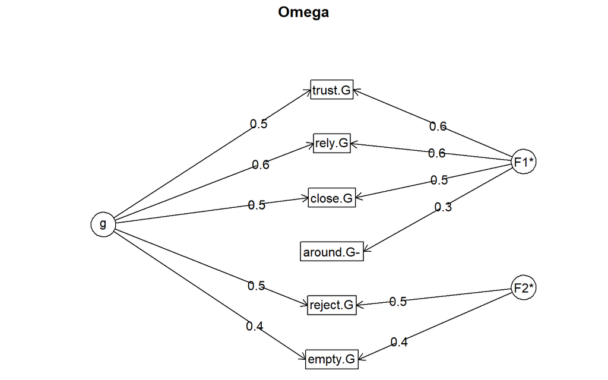

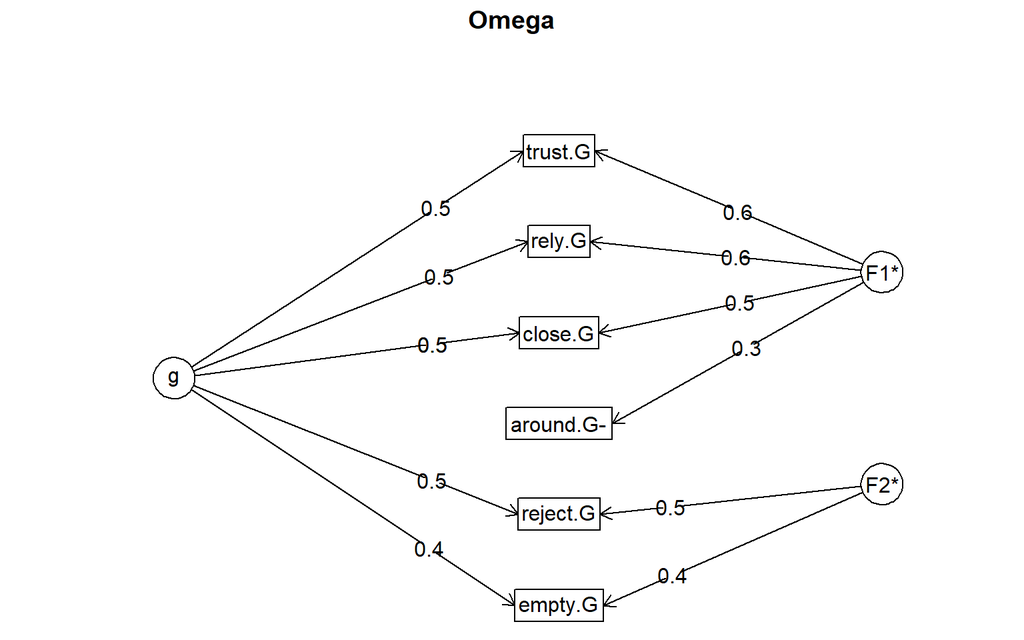

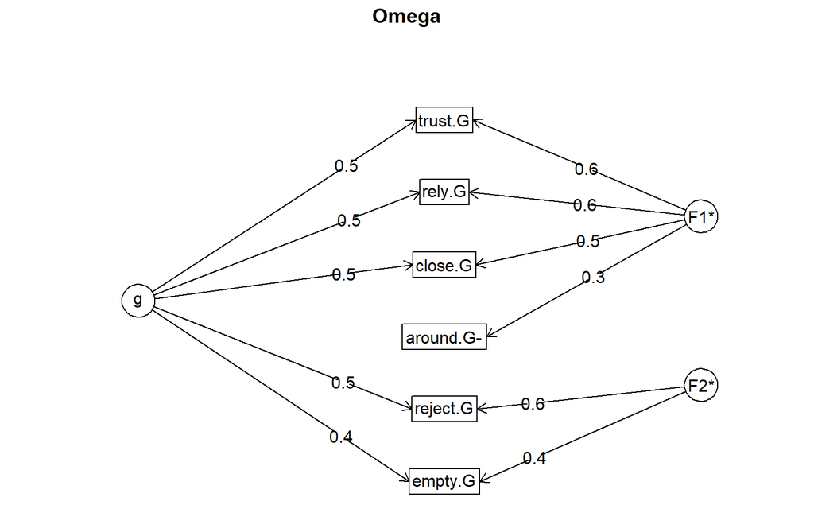

```
##   ImputationMethod ReliMethod rhoE2 rhoE3 Alpha Omega rho_MC
## 1              lwd        Sum 0.738 0.737 0.620 0.739  0.775
## 2         mean_imp        Sum 0.731 0.730 0.610 0.731  0.768
## 3          det_imp        Sum 0.740 0.740 0.619 0.741  0.777
## 4          sto_imp        Sum 0.737 0.736 0.615 0.737  0.774
```

```r
relisens(DJGLS[-1], 2, method = "sum")
```

```r
relisens(DJGLS[-1], 2, method = "image")
```

```
##   ImputationMethod ReliMethod rhoE2 rhoE3 Alpha Omega
## 1              lwd        ML1 0.810 0.810 0.675 0.810
## 2              lwd        ML2 0.598 0.600 0.365 0.597
## 3         mean_imp        ML1 0.803 0.805 0.671 0.802
## 4         mean_imp        ML2 0.602 0.603 0.358 0.602
## 5          det_imp        ML1 0.811 0.813 0.677 0.811
## 6          det_imp        ML2 0.610 0.611 0.369 0.610
## 7          sto_imp        ML1 0.808 0.811 0.675 0.808
## 8          sto_imp        ML2 0.605 0.606 0.362 0.605
```

```r
source("crelisens.R")
crelisens(DJGLS[-1], items.until = 3)
```

```
## Number of categories should be increased  in order to count frequencies.
```

```
## Number of categories should be increased  in order to count frequencies.
```

```
## Number of categories should be increased  in order to count frequencies.
```

```
##   ImputationMethod rho_T rho_MT rho_C rho_BF rho_SOF rho_CF
## 1              lwd 0.612  0.697 0.670  0.743   0.744  0.744
## 2         mean_imp 0.603  0.690 0.661  0.733   0.737  0.737
## 3          det_imp 0.612  0.700 0.670  0.745   0.747  0.747
## 4          sto_imp 0.610  0.697 0.668  0.741   0.744  0.744
```

#### DJGLS per factor

##### SLF - Social loneliness factor

```r
SLF <- DJGLS. %>% select(rely.G, trust.G, close.G)
SLF <- SLF[!rowSums(is.na(SLF)) > 1,]

relisens(SLF, 1, method = "score")
```

```
##   ImputationMethod ReliMethod rhoE2 rhoE3 Alpha rhoScore McDonald Regression
## 1              lwd     Score1 0.817 0.817 0.807    0.817    0.817      0.817
## 2         mean_imp     Score1 0.806 0.806 0.798    0.806    0.806      0.806
## 3          det_imp     Score1 0.820 0.820 0.811    0.820    0.820      0.820
## 4          sto_imp     Score1 0.815 0.815 0.806    0.815    0.815      0.815
##   Bartlett
## 1    0.817
## 2    0.806
## 3    0.820
## 4    0.815
```

```r
relisens(SLF, 1, method = "sum")
```

```
## Omega_h for 1 factor is not meaningful, just omega_t
```

```
## Omega_h for 1 factor is not meaningful, just omega_t
```

```
## Omega_h for 1 factor is not meaningful, just omega_t
```

```
## Omega_h for 1 factor is not meaningful, just omega_t
```

```
##   ImputationMethod ReliMethod rhoE2 rhoE3 Alpha Omega rho_MC
## 1              lwd        Sum 0.814 0.814 0.814 0.814  0.814
## 2         mean_imp        Sum 0.804 0.804 0.804 0.804  0.804
## 3          det_imp        Sum 0.818 0.818 0.818 0.818  0.818
## 4          sto_imp        Sum 0.812 0.812 0.812 0.812  0.812
```

```r
relisens(SLF, 1, method = "image")
```

```
##   ImputationMethod ReliMethod rhoE2 rhoE3 Alpha Omega
## 1              lwd        ML1 0.816 0.816 0.814 0.816
## 2         mean_imp        ML1 0.805 0.805 0.804 0.805
## 3          det_imp        ML1 0.819 0.819 0.817 0.819
## 4          sto_imp        ML1 0.815 0.815 0.814 0.815
```

```r
crelisens(SLF, items.until = 3)
```

```
## Number of categories should be increased  in order to count frequencies.
```

```
## Number of categories should be increased  in order to count frequencies.
```

```
##   ImputationMethod rho_T rho_MT rho_C rho_BF rho_SOF rho_CF
## 1              lwd 0.812     NA 0.816     NA      NA     NA
## 2         mean_imp 0.802     NA 0.806     NA      NA     NA
## 3          det_imp 0.816     NA 0.820     NA      NA     NA
## 4          sto_imp 0.811     NA 0.815     NA      NA     NA
```

##### ELF - Emotional loneliness factor

```r
ELF <- DJGLS. %>% select(empty.G, around.G, reject.G)
ELF <- ELF[!rowSums(is.na(ELF)) > 1,]

relisens(ELF, 1, method = "score")
```

```
##   ImputationMethod ReliMethod rhoE2 rhoE3 Alpha rhoScore McDonald Regression
## 1              lwd     Score1 0.716 0.716 0.261    0.716    0.716      0.716
## 2         mean_imp     Score1 0.780 0.780 0.177    0.780    0.780      0.780
## 3          det_imp     Score1 0.756 0.756 0.225    0.756    0.756      0.756
## 4          sto_imp     Score1 0.793 0.793 0.175    0.793    0.793      0.793
##   Bartlett
## 1    0.716
## 2    0.780
## 3    0.756
## 4    0.793
```

```r
relisens(ELF, 1, method = "sum")
```

```
## Omega_h for 1 factor is not meaningful, just omega_t
```

```
## Omega_h for 1 factor is not meaningful, just omega_t
```

```
## Omega_h for 1 factor is not meaningful, just omega_t
```

```
## Omega_h for 1 factor is not meaningful, just omega_t
```

```
##   ImputationMethod ReliMethod rhoE2 rhoE3 Alpha Omega rho_MC
## 1              lwd        Sum 0.485 0.485 0.370 0.485  0.485
## 2         mean_imp        Sum 0.493 0.493 0.365 0.493  0.493
## 3          det_imp        Sum 0.499 0.499 0.378 0.499  0.499
## 4          sto_imp        Sum 0.481 0.481 0.377 0.481  0.481
```

```r
relisens(ELF, 1, method = "image")
```

```
##   ImputationMethod ReliMethod rhoE2 rhoE3 Alpha Omega
## 1              lwd        ML1 0.686 0.686 0.415 0.686
## 2         mean_imp        ML1 0.734 0.734 0.390 0.734
## 3          det_imp        ML1 0.717 0.717 0.416 0.717
## 4          sto_imp        ML1 0.750 0.750 0.398 0.750
```

```r
crelisens(ELF, items.until = 3)
```

```
## Number of categories should be increased  in order to count frequencies.
```

```
## Number of categories should be increased  in order to count frequencies.
```

```
##   ImputationMethod rho_T rho_MT rho_C rho_BF rho_SOF rho_CF
## 1              lwd 0.350     NA 0.442     NA      NA     NA
## 2         mean_imp 0.344     NA 0.445     NA      NA     NA
## 3          det_imp 0.357     NA 0.453     NA      NA     NA
## 4          sto_imp 0.348     NA 0.450     NA      NA     NA
```

### ALS

```r
relisens(CSNe[-1], 1, method = "score")
```

```
##   ImputationMethod ReliMethod rhoE2 rhoE3 Alpha rhoScore McDonald Regression
## 1              lwd     Score1 0.856 0.856 0.723    0.856    0.856      0.856
## 2         mean_imp     Score1 0.853 0.853 0.720    0.853    0.853      0.853
## 3          det_imp     Score1 0.856 0.856 0.721    0.856    0.856      0.856
## 4          sto_imp     Score1 0.855 0.855 0.721    0.855    0.855      0.855
##   Bartlett
## 1    0.856
## 2    0.853
## 3    0.856
## 4    0.855
```

```r
relisens(CSNe[-1], 1, method = "sum")
```

```
## Omega_h for 1 factor is not meaningful, just omega_t
```

```
## Omega_h for 1 factor is not meaningful, just omega_t
```

```
## Omega_h for 1 factor is not meaningful, just omega_t
```

```
## Omega_h for 1 factor is not meaningful, just omega_t
```

```
##   ImputationMethod ReliMethod rhoE2 rhoE3 Alpha Omega rho_MC
## 1              lwd        Sum 0.805 0.807 0.794 0.805  0.805
## 2         mean_imp        Sum 0.802 0.804 0.790 0.802  0.802
## 3          det_imp        Sum 0.805 0.806 0.793 0.804  0.805
## 4          sto_imp        Sum 0.803 0.805 0.791 0.803  0.803
```

```r
relisens(CSNe[-1], 1, method = "image")
```

```
##   ImputationMethod ReliMethod rhoE2 rhoE3 Alpha Omega
## 1              lwd        ML1 0.836 0.836 0.795 0.836
## 2         mean_imp        ML1 0.833 0.834 0.792 0.833
## 3          det_imp        ML1 0.836 0.836 0.794 0.835
## 4          sto_imp        ML1 0.835 0.835 0.793 0.835
```

```r
crelisens(CSNe[-1], 4)
```

```
## Number of categories should be increased  in order to count frequencies.
## Number of categories should be increased  in order to count frequencies.
```

```
##   ImputationMethod rho_T rho_MT rho_C rho_BF rho_SOF rho_CF
## 1              lwd 0.788     NA 0.814     NA      NA     NA
## 2         mean_imp 0.785     NA 0.811     NA      NA     NA
## 3          det_imp 0.788     NA 0.813     NA      NA     NA
## 4          sto_imp 0.787     NA 0.813     NA      NA     NA
```

#### Influence of CS as neutral (CSNe) versus CS as missing value (CSNA)

```r
CS_diff <- function(reliNe, reliNA){
  diffNANe <- reliNA %>% as.data.frame()
  #diff[3:10] <- reliNALS[3:10] - reliNe[3:10]
  diffNANe[3:6] <- reliNe[3:6] - reliNA[3:6]
  diffNANe[3:6] <- diffNANe[3:6] %>% format(digits = 2)
  diffNANe
}
# factor scores
reliNA <- CSNA[-1] %>% relisens(1, round = F)
reliNe <- CSNe[-1] %>% relisens(1, round = F)
CS_diff(reliNe, reliNA)
```

```
##   ImputationMethod ReliMethod rhoE2 rhoE3  Alpha rhoScore  McDonald Regression
## 1              lwd     Score1 0.022 0.022 0.0072    0.022 0.8339193  0.8339193
## 2         mean_imp     Score1 0.036 0.036 0.0182    0.036 0.8173528  0.8173528
## 3          det_imp     Score1 0.005 0.005 0.0023    0.005 0.8511815  0.8511815
## 4          sto_imp     Score1 0.012 0.012 0.0066    0.012 0.8426978  0.8426978
##    Bartlett
## 1 0.8339193
## 2 0.8173528
## 3 0.8511815
## 4 0.8426978
```

```r
# unweighted sums
reliNA <- CSNA[-1] %>% relisens(1, round = F, method = "sum")
```

```
## Omega_h for 1 factor is not meaningful, just omega_t
```

```
## Omega_h for 1 factor is not meaningful, just omega_t
```

```
## Omega_h for 1 factor is not meaningful, just omega_t
```

```
## Omega_h for 1 factor is not meaningful, just omega_t
```

```r
reliNe <- CSNe[-1] %>% relisens(1, round = F, method = "sum")
```

```
## Omega_h for 1 factor is not meaningful, just omega_t
```

```
## Omega_h for 1 factor is not meaningful, just omega_t
```

```
## Omega_h for 1 factor is not meaningful, just omega_t
```

```
## Omega_h for 1 factor is not meaningful, just omega_t
```

```r
CS_diff(reliNe, reliNA)
```

```
##   ImputationMethod ReliMethod  rhoE2  rhoE3  Alpha  Omega    rho_MC
## 1              lwd        Sum 0.0195 0.0216 0.0182 0.0190 0.7857877
## 2         mean_imp        Sum 0.0327 0.0337 0.0324 0.0325 0.7692267
## 3          det_imp        Sum 0.0058 0.0071 0.0055 0.0055 0.7988672
## 4          sto_imp        Sum 0.0159 0.0170 0.0166 0.0157 0.7875890
```

```r
# factor images
reliNA <- CSNA[-1] %>% relisens(1, round = F, method = "image")
reliNe <- CSNe[-1] %>% relisens(1, round = F, method = "image")
CS_diff(reliNe, reliNA)
```

```
##   ImputationMethod ReliMethod  rhoE2  rhoE3  Alpha  Omega
## 1              lwd        ML1 0.0194 0.0202 0.0189 0.0192
## 2         mean_imp        ML1 0.0319 0.0324 0.0326 0.0319
## 3          det_imp        ML1 0.0044 0.0049 0.0058 0.0043
## 4          sto_imp        ML1 0.0150 0.0156 0.0155 0.0149
```

# Comparison of the loneliness item of Allardt’s Life Satisfaction Scale with De Jong Gierveld Loneliness Scale

Load data:

```r
load("wrangled-data.RData")
library(tidyverse)
```

Exploring how the loneliness item of ALS (ALS-L) relates to the validated DJGLS-6.

### Exploring distributions

Examining the distributions of the loneliness item of ALS (ALS-L/alone.A?) and the DJGLS-6.

Plotting the distribution of the reversed DJGLS (so that higher = more lonely) with lonely.A responses as the fill:

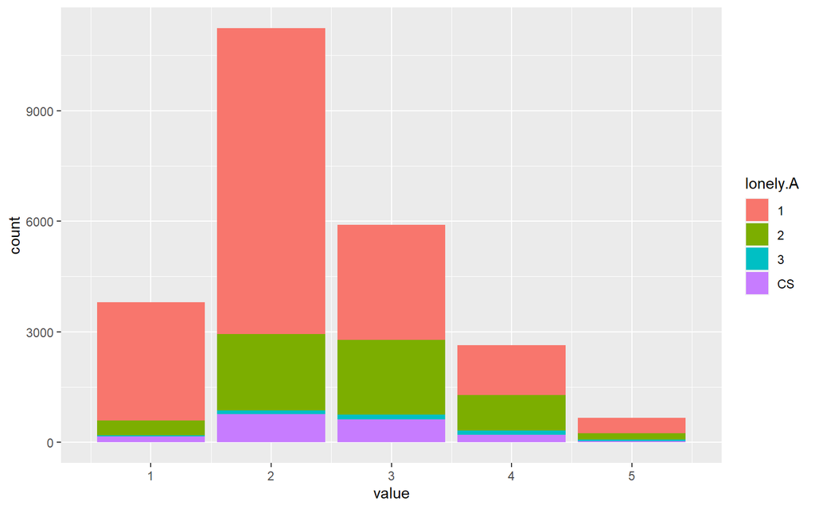

```r
# joining the data of both scales to one set (no recoding of CS or imputations done)
SCALES_rev <- full_join(ALS, DJGLS, by = "ID")


# transforming the dataframe into long form
alone.G_L <- SCALES_rev %>%
  select(ID, lonely.A, all_of(Gierveld)) %>%
  mutate_all(~ifelse(lonely.A==4, "CS", .x)) %>%
  pivot_longer(cols = c("rely.G", "trust.G", "close.G", "empty.G", "around.G", "reject.G"))

# plotting
alone.G_L %>%
  ggplot(aes(x = value)) +
  geom_bar(aes(fill = lonely.A)) +
  scale_x_continuous(limits = c(.5,5.5))
```

```r
#### 3744 removed rows???
```

The bar plot shows the distribution of the DJGLS with reversions, where 5 = very lonely, 1 = not lonely at all. The colors signify the reversed lonely.A, where 1 = not lonely at all (red), 3 = very lonely (blue).

Visually, it doesn’t seem that the distribution of lonely.A is similar to the one of DJGLS: those very lonely according to lonely.A spread rather evenly in their responses in DJGLS, and there’s a big proportion of “not at all lonely” respondents even in the loneliest response category of DJGLS. As a side note, this distribution does seem to somewhat support the idea of interpreting CS responses as neutral responses, as those tend to heavily place in the neutral responses of DJGLS. However, this graph is per item, so it could be, for example, that some items will be low even if the total scale result would be high.

Let’s see what the distribution of lonely.A looks like compared to the row means of DJGLS:

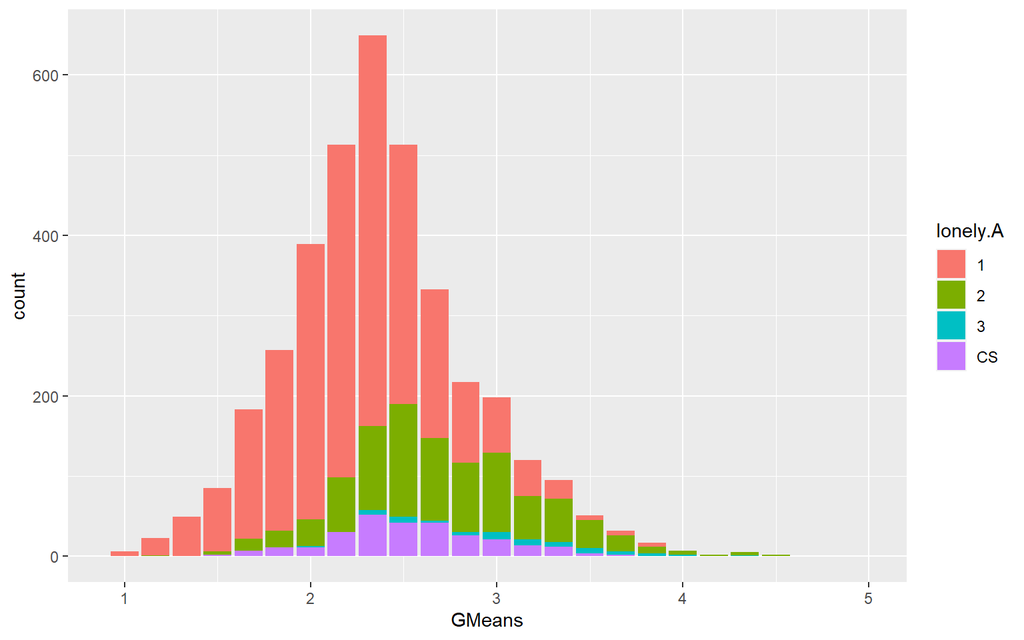

```r
# creating a dataframe with the row means of DJGLS and lonely.A
GMeans_aloNA <- SCALES_rev %>%
  select(ID, lonely.A, all_of(Gierveld)) %>%
  mutate(GMeans = rowMeans(.[,3:8], na.rm = F)) # na.rm breaks the distribution. But note that because of this rows with missing values have been removed!

# plotting
GMeans_aloNA  %>%
  mutate_all(~ifelse(lonely.A==4, "CS", .x)) %>%
  ggplot(aes(x = GMeans)) +
  geom_bar(aes(fill = lonely.A)) +
  scale_x_continuous(limits = c(.9,5))
```

Here the distribution looks more like what we would expect, seeing more of the pattern of high loneliness responses to lonely.A corresponding to high loneliness responses of the DJGLS. Very few of those who respond to lonely.A “not lonely at all” will be lonely (>3) in the responses of the DJGLS. However, it does seem that lonely.A is worse at recognizing the loneliest: many of the loneliest according to the DJGLS will still respond to the lonely.A with 2 (somewhat lonely). This graph, too, seems to support the interpretation of CS as neutral: the distributions of “cannot say” and “somewhat lonely” (2) match decently.

Further examining the distributions with the factors of the DJGLS considered separately.

Emotional loneliness and lonely.A:

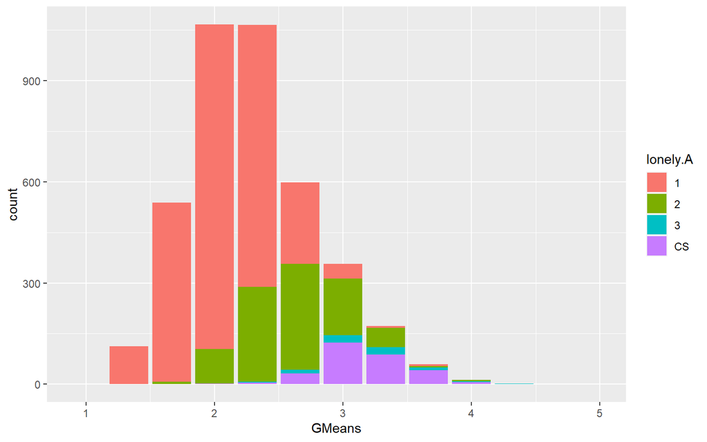

```r
# Emotional loneliness factor of DJGLS and lonely.A

EmoMeans_aloNA <- SCALES_rev %>%
  select(ID, empty.G, around.G, reject.G, lonely.A) %>%
  mutate(GMeans = rowMeans(.[,3:5], na.rm = F)) # na.rm breaks the distribution. But note that because of this rows with missing values have been removed!

# plotting
EmoMeans_aloNA  %>%
  mutate_all(~ifelse(lonely.A==4, "CS", .x)) %>%
  ggplot(aes(x = GMeans)) +
  geom_bar(aes(fill = lonely.A)) +
  scale_x_continuous(limits = c(.9,5))
```

Social loneliness and lonely.A:

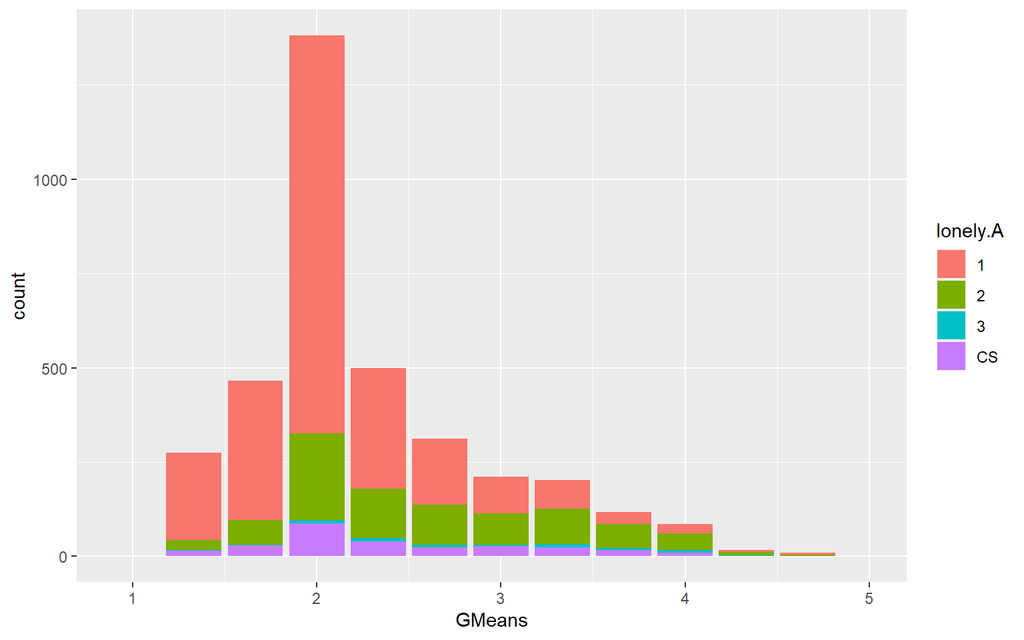

```r
# Social loneliness factor of DJGLS and lonely.A

SosMeans_aloNA <- SCALES_rev %>%
  select(ID, lonely.A, rely.G, trust.G, close.G) %>%
  mutate(GMeans = rowMeans(.[,3:5], na.rm = F)) # na.rm breaks the distribution. But note that because of this rows with missing values have been removed!

# plotting
SosMeans_aloNA  %>%
  mutate_all(~ifelse(lonely.A==4, "CS", .x)) %>%
  ggplot(aes(x = GMeans)) +
  geom_bar(aes(fill = lonely.A)) +
  scale_x_continuous(limits = c(.9,5))
```

We can see that here, lonely.A seems to be a lot more closely related to emotional loneliness than social loneliness.

### Joining the datasets

Before further analyses, joining the datasets and performing imputation for the new dataset which combines DJGLS and ALS (CSNe version of the data).

```r
# joining the datasets:
aloNe <- CSNe %>% select(ID, lonely.A) # CSNe version of lonely.A
G_aloNe <- full_join(DJGLS., aloNe, by = "ID")

# checking missing values
apply(G_aloNe,2,p) # 1.65
```

```
##         ID     rely.G    trust.G    close.G    empty.G   around.G   reject.G
## 0.00000000 0.09989282 0.08595927 0.06302251 0.10868167 0.10075027 0.09646302
##   lonely.A
## 0.02100750
```

#### Imputation

```r
# Imputations
library(mice)
library(haven)
G_aloNe_mean <- mean_imp(G_aloNe) # mean imputation
G_aloNe_det <- det_imp(G_aloNe) # deterministic regression
G_aloNe_sto <- sto_imp(G_aloNe) # stochastic regression imputation
```

### Correlations

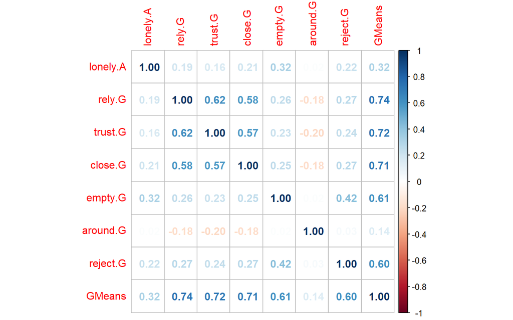

```r
library(corrplot)
# Correlation between lonely.A and row means of the DJGLS:

# plotting
GMeans_aloNA[-1] %>%
  cor(use = "complete.obs") %>%
  corrplot(method = "number")
```

```r
# the correlation
cor(GMeans_aloNA$lonely.A,
    GMeans_aloNA$GMeans,
    use = "complete.obs") %>%
  round(2)
```

```
## [1] 0.32
```

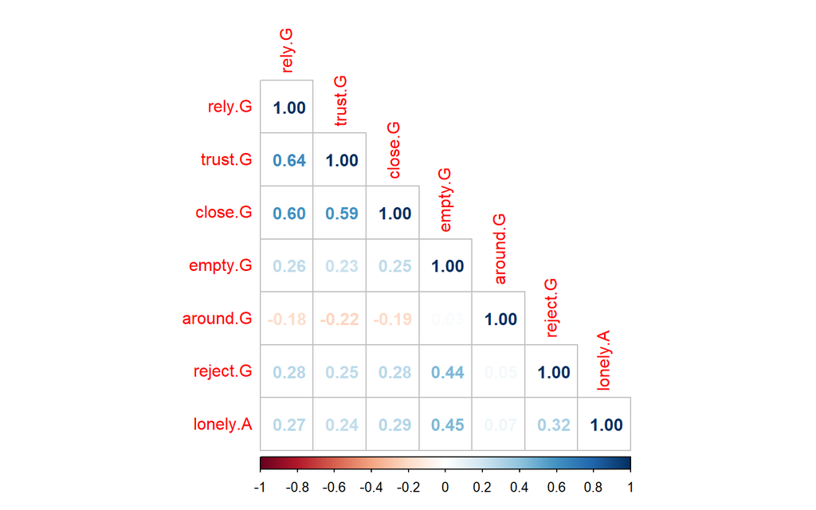

```r
# item-wise correlations without means of DJGLS, with deterministic imputed data, CS in alone.A recoded as neutral (CSNe)
G_aloNe_det[-1] %>%
  cor(use = "complete.obs") %>%
  corrplot(method = "number", type = "lower")
```

```r
# Correlations with factors of the DJGLS separately:

# correlation between lonely.A and the emotional factor of DJGLS
cor(EmoMeans_aloNA$lonely.A,
    EmoMeans_aloNA$GMeans,
    use = "complete.obs", ) %>%
  round(2)
```

[output not shown]

```r
# correlation between lonely.A and the social factor of DJGLS
cor(SosMeans_aloNA$lonely.A,
    SosMeans_aloNA$GMeans,
    use = "complete.obs") %>%
  round(2)
```

```
## [1] 0.22
```

```r
# Correlations calculated through factor scores

library(psych)

# factors as variables
EMO <- G_aloNe_det %>% select(empty.G, reject.G, around.G)
SOS <- G_aloNe_det %>% select(rely.G, trust.G, close.G)

# factor scores of social loneliness factor, emotional loneliness factor and alone.A
SOS_fs <- factor.scores(SOS, fa(SOS,1))
EMO_fs <- factor.scores(EMO, fa(EMO,1))
A_fs <- factor.scores(G_aloNe_det[2], fa(G_aloNe_det[2], 1))

# correlations from the factor scores
cor(SOS_fs$scores,A_fs$scores) # between SLF and alone.A
```

[output not shown]

```r
cor(EMO_fs$scores,A_fs$scores) # between ELF and alone.A
```

```
##           MR1
## MR1 0.3034909
```

```r
# correlation through the factors scores between DJGLS (as single-factor) and alone.A:
FULL_fs <- factor.scores(G_aloNe_det[3:8], fa(G_aloNe_det[3:8],1))
cor(FULL_fs$scores, A_fs$scores)
```

```
##           MR1
## MR1 0.6296296
```

### Fitting linear models

Fitting a linear model with all items of the DJGLS:

```r
# fitting the model, the items of DJGLS as independent variables and alone.A as the dependent variable
fit_aloNe <- lm(lonely.A ~ empty.G + rely.G + trust.G + close.G + around.G + reject.G, na.omit(G_aloNe_det))
summary(fit_aloNe)
```

```
##
## Call:
## lm(formula = lonely.A ~ empty.G + rely.G + trust.G + close.G +
##     around.G + reject.G, data = na.omit(G_aloNe_det))
##
## Residuals:
##     Min      1Q  Median      3Q     Max
## -1.2465 -0.3158 -0.1047  0.3505  1.9428
##
## Coefficients:
##             Estimate Std. Error t value Pr(>|t|)
## (Intercept) 0.200308   0.038221   5.241 1.67e-07 ***
## empty.G     0.209544   0.008763  23.913  < 2e-16 ***
## rely.G      0.045858   0.010299   4.453 8.68e-06 ***
## trust.G     0.020586   0.009670   2.129   0.0333 *
## close.G     0.077483   0.010883   7.120 1.25e-12 ***
## around.G    0.057733   0.007812   7.390 1.73e-13 ***
## reject.G    0.075532   0.010483   7.205 6.71e-13 ***
## ---
## Signif. codes:  0 '***' 0.001 '**' 0.01 '*' 0.05 '.' 0.1 ' ' 1
##
## Residual standard error: 0.4397 on 4658 degrees of freedom
## Multiple R-squared:  0.2594, Adjusted R-squared:  0.2584
## F-statistic: 271.9 on 6 and 4658 DF,  p-value: < 2.2e-16
```

```r
# calculating odds ratios (OR) with confidence intervals (CI)
OR <- coef(fit_aloNe) %>% exp
CI <- confint(fit_aloNe) %>% exp
cbind(OR, CI)
```

```
##                   OR    2.5 %   97.5 %
## (Intercept) 1.221779 1.133575 1.316846
## empty.G     1.233116 1.212113 1.254484
## rely.G      1.046926 1.025999 1.068279
## trust.G     1.020799 1.001629 1.040336
## close.G     1.080564 1.057753 1.103866
## around.G    1.059432 1.043330 1.075784
## reject.G    1.078458 1.056521 1.100851
```

The sample size is large so the p-values are low, but the R-squared is low: the items of DJGLS only explain 26 % of the variance of lonely.A.

Fitting linear models for the factors of the DJGLS separately:

```r
# a model with the items of emotional loneliness factor as independent variables and lonely.A as the dependent variable
fit_emo_aloNe <- lm(lonely.A ~ empty.G + around.G + reject.G, na.omit(G_aloNe_det))
summary(fit_emo_aloNe)
```

```
##
## Call:
## lm(formula = lonely.A ~ empty.G + around.G + reject.G, data = na.omit(G_aloNe_det))
##
## Residuals:
##     Min      1Q  Median      3Q     Max
## -1.2819 -0.2927 -0.1343  0.4084  1.8458
##
## Coefficients:
##             Estimate Std. Error t value Pr(>|t|)
## (Intercept) 0.471251   0.034019  13.852  < 2e-16 ***
## empty.G     0.232887   0.008817  26.413  < 2e-16 ***
## around.G    0.028327   0.007705   3.676 0.000239 ***
## reject.G    0.112243   0.010418  10.774  < 2e-16 ***
## ---
## Signif. codes:  0 '***' 0.001 '**' 0.01 '*' 0.05 '.' 0.1 ' ' 1
##
## Residual standard error: 0.4498 on 4661 degrees of freedom
## Multiple R-squared:  0.2243, Adjusted R-squared:  0.2238
## F-statistic: 449.3 on 3 and 4661 DF,  p-value: < 2.2e-16
```

```r
# a model with the items of social loneliness factor as independent variables and lonely.A as the dependent variable:
fit_sos_aloNe <- lm(lonely.A ~ rely.G + trust.G + close.G, na.omit(G_aloNe_det))
summary(fit_sos_aloNe)
```

```
##
## Call:
## lm(formula = lonely.A ~ rely.G + trust.G + close.G, data = na.omit(G_aloNe_det))
##
## Residuals:
##     Min      1Q  Median      3Q     Max
## -0.9839 -0.3259 -0.2149  0.4575  1.8934
##
## Coefficients:
##             Estimate Std. Error t value Pr(>|t|)
## (Intercept)  0.88726    0.02187  40.572  < 2e-16 ***
## rely.G       0.08057    0.01124   7.170 8.68e-13 ***
## trust.G      0.02772    0.01057   2.623  0.00875 **
## close.G      0.11104    0.01185   9.369  < 2e-16 ***
## ---
## Signif. codes:  0 '***' 0.001 '**' 0.01 '*' 0.05 '.' 0.1 ' ' 1
##
## Residual standard error: 0.4845 on 4661 degrees of freedom
## Multiple R-squared:    0.1,  Adjusted R-squared:  0.09942
## F-statistic: 172.6 on 3 and 4661 DF,  p-value: < 2.2e-16
```

The R-squared is about 22 % for emotional loneliness and 10% for social loneliness. Conforming to plots drawn earlier, it shows that lonely.A is more strongly related to emotional loneliness than social loneliness.

### EFA

Performing EFA for a model where alone.A is added to the DJGLS-6, first with two-factor structure and then with three-factor structure:

```r
# With 2 factor structure

# and also comparing the influence of imputation method
fa(G_aloNe[-1], 2) # no imputation
```

```
## Factor Analysis using method =  minres
## Call: fa(r = G_aloNe[-1], nfactors = 2)
## Standardized loadings (pattern matrix) based upon correlation matrix
##            MR1   MR2   h2   u2 com
## rely.G    0.76  0.04 0.61 0.39 1.0
## trust.G   0.80 -0.03 0.62 0.38 1.0
## close.G   0.72  0.05 0.55 0.45 1.0
## empty.G  -0.03  0.74 0.53 0.47 1.0
## around.G -0.36  0.24 0.11 0.89 1.7
## reject.G  0.08  0.53 0.33 0.67 1.0
## lonely.A  0.07  0.55 0.34 0.66 1.0
##
##                        MR1  MR2
## SS loadings           1.89 1.20
## Proportion Var        0.27 0.17
## Cumulative Var        0.27 0.44
## Proportion Explained  0.61 0.39
## Cumulative Proportion 0.61 1.00
##
##  With factor correlations of
##      MR1  MR2
## MR1 1.00 0.45
## MR2 0.45 1.00
##
## Mean item complexity =  1.1
## Test of the hypothesis that 2 factors are sufficient.
##
## df null model =  21  with the objective function =  1.69 with Chi Square =  7863.14
## df of  the model are 8  and the objective function was  0.01
##
## The root mean square of the residuals (RMSR) is  0.02
## The df corrected root mean square of the residuals is  0.03
##
## The harmonic n.obs is  4129 with the empirical chi square  44.42  with prob <  4.7e-07
## The total n.obs was  4665  with Likelihood Chi Square =  62.31  with prob <  1.6e-10
##
## Tucker Lewis Index of factoring reliability =  0.982
## RMSEA index =  0.038  and the 90 % confidence intervals are  0.03 0.047
## BIC =  -5.28
## Fit based upon off diagonal values = 1
## Measures of factor score adequacy
##                                                    MR1  MR2
## Correlation of (regression) scores with factors   0.91 0.84
## Multiple R square of scores with factors          0.83 0.70
## Minimum correlation of possible factor scores     0.65 0.40
```

```r
fa(G_aloNe_mean[-1], 2) # mean imputation
```

```
## Factor Analysis using method =  minres
## Call: fa(r = G_aloNe_mean[-1], nfactors = 2)
## Standardized loadings (pattern matrix) based upon correlation matrix
##            MR1   MR2   h2   u2 com
## rely.G    0.75  0.04 0.58 0.42 1.0
## trust.G   0.79 -0.03 0.60 0.40 1.0
## close.G   0.70  0.05 0.52 0.48 1.0
## empty.G  -0.03  0.73 0.51 0.49 1.0
## around.G -0.35  0.23 0.10 0.90 1.7
## reject.G  0.08  0.52 0.32 0.68 1.0
## lonely.A  0.07  0.53 0.32 0.68 1.0
##
##                        MR1  MR2
## SS loadings           1.81 1.14
## Proportion Var        0.26 0.16
## Cumulative Var        0.26 0.42
## Proportion Explained  0.61 0.39
## Cumulative Proportion 0.61 1.00
##
##  With factor correlations of
##      MR1  MR2
## MR1 1.00 0.44
## MR2 0.44 1.00
##
## Mean item complexity =  1.1
## Test of the hypothesis that 2 factors are sufficient.
##
## df null model =  21  with the objective function =  1.52 with Chi Square =  7091.13
## df of  the model are 8  and the objective function was  0.01
##
## The root mean square of the residuals (RMSR) is  0.02
## The df corrected root mean square of the residuals is  0.03
##
## The harmonic n.obs is  4665 with the empirical chi square  49.27  with prob <  5.6e-08
## The total n.obs was  4665  with Likelihood Chi Square =  57.57  with prob <  1.4e-09
##
## Tucker Lewis Index of factoring reliability =  0.982
## RMSEA index =  0.036  and the 90 % confidence intervals are  0.028 0.046
## BIC =  -10.02
## Fit based upon off diagonal values = 1
## Measures of factor score adequacy
##                                                    MR1  MR2
## Correlation of (regression) scores with factors   0.90 0.83
## Multiple R square of scores with factors          0.81 0.68
## Minimum correlation of possible factor scores     0.62 0.36
```

```r
fa(G_aloNe_det[-1], 2) # deterministic regression
```

```
## Factor Analysis using method =  minres
## Call: fa(r = G_aloNe_det[-1], nfactors = 2)
## Standardized loadings (pattern matrix) based upon correlation matrix
##            MR1   MR2   h2   u2 com
## rely.G    0.78  0.04 0.63 0.37 1.0
## trust.G   0.82 -0.04 0.64 0.36 1.0
## close.G   0.73  0.06 0.57 0.43 1.0
## empty.G  -0.03  0.75 0.55 0.45 1.0
## around.G -0.37  0.25 0.11 0.89 1.8
## reject.G  0.09  0.54 0.34 0.66 1.0
## lonely.A  0.07  0.57 0.36 0.64 1.0
##
##                        MR1  MR2
## SS loadings           1.96 1.26
## Proportion Var        0.28 0.18
## Cumulative Var        0.28 0.46
## Proportion Explained  0.61 0.39
## Cumulative Proportion 0.61 1.00
##
##  With factor correlations of
##      MR1  MR2
## MR1 1.00 0.45
## MR2 0.45 1.00
##
## Mean item complexity =  1.1
## Test of the hypothesis that 2 factors are sufficient.
##
## df null model =  21  with the objective function =  1.83 with Chi Square =  8513.71
## df of  the model are 8  and the objective function was  0.01
##
## The root mean square of the residuals (RMSR) is  0.02
## The df corrected root mean square of the residuals is  0.03
##
## The harmonic n.obs is  4665 with the empirical chi square  51.78  with prob <  1.9e-08
## The total n.obs was  4665  with Likelihood Chi Square =  67.98  with prob <  1.2e-11
##
## Tucker Lewis Index of factoring reliability =  0.981
## RMSEA index =  0.04  and the 90 % confidence intervals are  0.032 0.049
## BIC =  0.4
## Fit based upon off diagonal values = 1
## Measures of factor score adequacy
##                                                    MR1  MR2
## Correlation of (regression) scores with factors   0.91 0.85
## Multiple R square of scores with factors          0.84 0.72
## Minimum correlation of possible factor scores     0.67 0.43
```

```r
fa(G_aloNe_sto[-1], 2) # stochastic regression
```

```
## Factor Analysis using method =  minres
## Call: fa(r = G_aloNe_sto[-1], nfactors = 2)
## Standardized loadings (pattern matrix) based upon correlation matrix
##            MR1   MR2   h2   u2 com
## rely.G    0.76  0.04 0.60 0.40 1.0
## trust.G   0.81 -0.04 0.62 0.38 1.0
## close.G   0.72  0.05 0.56 0.44 1.0
## empty.G  -0.03  0.74 0.53 0.47 1.0
## around.G -0.35  0.24 0.11 0.89 1.8
## reject.G  0.07  0.54 0.33 0.67 1.0
## lonely.A  0.08  0.55 0.34 0.66 1.0
##
##                        MR1  MR2
## SS loadings           1.89 1.21
## Proportion Var        0.27 0.17
## Cumulative Var        0.27 0.44
## Proportion Explained  0.61 0.39
## Cumulative Proportion 0.61 1.00
##
##  With factor correlations of
##      MR1  MR2
## MR1 1.00 0.44
## MR2 0.44 1.00
##
## Mean item complexity =  1.1
## Test of the hypothesis that 2 factors are sufficient.
##
## df null model =  21  with the objective function =  1.68 with Chi Square =  7839.3
## df of  the model are 8  and the objective function was  0.01
##
## The root mean square of the residuals (RMSR) is  0.02
## The df corrected root mean square of the residuals is  0.03
##
## The harmonic n.obs is  4665 with the empirical chi square  52.98  with prob <  1.1e-08
## The total n.obs was  4665  with Likelihood Chi Square =  68.77  with prob <  8.6e-12
##
## Tucker Lewis Index of factoring reliability =  0.98
## RMSEA index =  0.04  and the 90 % confidence intervals are  0.032 0.049
## BIC =  1.18
## Fit based upon off diagonal values = 1
## Measures of factor score adequacy
##                                                    MR1  MR2
## Correlation of (regression) scores with factors   0.91 0.84
## Multiple R square of scores with factors          0.82 0.70
## Minimum correlation of possible factor scores     0.65 0.40
```

```r
  # differences from imputation method are small with two-factor       structure
```

```r
# With 3 factor structure

# and also comparing the influence of imputation method
fa(G_aloNe[-1], 3)
```

```
## Factor Analysis using method =  minres
## Call: fa(r = G_aloNe[-1], nfactors = 3)
## Standardized loadings (pattern matrix) based upon correlation matrix
##            MR1   MR2   MR3   h2     u2 com
## rely.G    0.77  0.01  0.03 0.61 0.3913 1.0
## trust.G   0.80 -0.02 -0.02 0.62 0.3754 1.0
## close.G   0.72  0.03  0.02 0.55 0.4512 1.0
## empty.G   0.05  0.25  0.41 0.34 0.6614 1.7
## around.G -0.35  0.11  0.15 0.10 0.8962 1.6
## reject.G  0.01 -0.03  0.82 0.65 0.3453 1.0
## lonely.A  0.00  1.00  0.00 1.00 0.0049 1.0
##
##                        MR1  MR2  MR3
## SS loadings           1.87 1.11 0.89
## Proportion Var        0.27 0.16 0.13
## Cumulative Var        0.27 0.43 0.55
## Proportion Explained  0.48 0.29 0.23
## Cumulative Proportion 0.48 0.77 1.00
##
##  With factor correlations of
##      MR1  MR2  MR3
## MR1 1.00 0.32 0.40
## MR2 0.32 1.00 0.41
## MR3 0.40 0.41 1.00
##
## Mean item complexity =  1.2
## Test of the hypothesis that 3 factors are sufficient.
##
## df null model =  21  with the objective function =  1.69 with Chi Square =  7863.14
## df of  the model are 3  and the objective function was  0
##
## The root mean square of the residuals (RMSR) is  0
## The df corrected root mean square of the residuals is  0.01
##
## The harmonic n.obs is  4129 with the empirical chi square  3.26  with prob <  0.35
## The total n.obs was  4665  with Likelihood Chi Square =  6.41  with prob <  0.093
##
## Tucker Lewis Index of factoring reliability =  0.997
## RMSEA index =  0.016  and the 90 % confidence intervals are  0 0.033
## BIC =  -18.93
## Fit based upon off diagonal values = 1
## Measures of factor score adequacy
##                                                    MR1  MR2  MR3
## Correlation of (regression) scores with factors   0.91 1.00 0.85
## Multiple R square of scores with factors          0.82 1.00 0.72
## Minimum correlation of possible factor scores     0.65 0.99 0.43
```

```r
fa(G_aloNe_mean[-1], 3)
```

```
## Factor Analysis using method =  minres
## Call: fa(r = G_aloNe_mean[-1], nfactors = 3)
## Standardized loadings (pattern matrix) based upon correlation matrix
##            MR1   MR2   MR3    h2     u2 com
## rely.G    0.75  0.01  0.03 0.578 0.4215 1.0
## trust.G   0.79 -0.02 -0.02 0.602 0.3983 1.0
## close.G   0.70  0.03  0.02 0.520 0.4799 1.0
## empty.G   0.05  0.23  0.41 0.321 0.6786 1.6
## around.G -0.34  0.10  0.16 0.099 0.9007 1.6
## reject.G  0.01 -0.03  0.80 0.627 0.3732 1.0
## lonely.A  0.00  1.00  0.00 0.995 0.0049 1.0
##
##                        MR1  MR2  MR3
## SS loadings           1.79 1.09 0.87
## Proportion Var        0.26 0.16 0.12
## Cumulative Var        0.26 0.41 0.53
## Proportion Explained  0.48 0.29 0.23
## Cumulative Proportion 0.48 0.77 1.00
##
##  With factor correlations of
##      MR1  MR2 MR3
## MR1 1.00 0.31 0.4
## MR2 0.31 1.00 0.4
## MR3 0.40 0.40 1.0
##
## Mean item complexity =  1.2
## Test of the hypothesis that 3 factors are sufficient.
##
## df null model =  21  with the objective function =  1.52 with Chi Square =  7091.13
## df of  the model are 3  and the objective function was  0
##
## The root mean square of the residuals (RMSR) is  0
## The df corrected root mean square of the residuals is  0.01
##
## The harmonic n.obs is  4665 with the empirical chi square  3.46  with prob <  0.33
## The total n.obs was  4665  with Likelihood Chi Square =  5.47  with prob <  0.14
##
## Tucker Lewis Index of factoring reliability =  0.998
## RMSEA index =  0.013  and the 90 % confidence intervals are  0 0.031
## BIC =  -19.87
## Fit based upon off diagonal values = 1
## Measures of factor score adequacy
##                                                    MR1  MR2  MR3
## Correlation of (regression) scores with factors   0.90 1.00 0.83
## Multiple R square of scores with factors          0.81 1.00 0.70
## Minimum correlation of possible factor scores     0.62 0.99 0.39
```

```r
fa(G_aloNe_det[-1], 3)
```

```
## Factor Analysis using method =  minres
## Call: fa(r = G_aloNe_det[-1], nfactors = 3)
## Standardized loadings (pattern matrix) based upon correlation matrix
##            MR1   MR2   MR3   h2     u2 com
## rely.G    0.80 -0.01  0.03 0.63 0.3668 1.0
## trust.G   0.81 -0.01 -0.06 0.64 0.3629 1.0
## close.G   0.75  0.00  0.04 0.57 0.4254 1.0
## empty.G  -0.01  1.00 -0.01 1.00 0.0048 1.0
## around.G -0.29 -0.06  0.39 0.20 0.7999 1.9
## reject.G  0.23  0.24  0.29 0.31 0.6899 2.9
## lonely.A  0.22  0.22  0.35 0.35 0.6535 2.4
##
##                        MR1  MR2  MR3
## SS loadings           2.07 1.20 0.43
## Proportion Var        0.30 0.17 0.06
## Cumulative Var        0.30 0.47 0.53
## Proportion Explained  0.56 0.32 0.12
## Cumulative Proportion 0.56 0.88 1.00
##
##  With factor correlations of
##      MR1  MR2  MR3
## MR1 1.00 0.33 0.13
## MR2 0.33 1.00 0.46
## MR3 0.13 0.46 1.00
##
## Mean item complexity =  1.6
## Test of the hypothesis that 3 factors are sufficient.
##
## df null model =  21  with the objective function =  1.83 with Chi Square =  8513.71
## df of  the model are 3  and the objective function was  0
##
## The root mean square of the residuals (RMSR) is  0.01
## The df corrected root mean square of the residuals is  0.01
##
## The harmonic n.obs is  4665 with the empirical chi square  5.33  with prob <  0.15
## The total n.obs was  4665  with Likelihood Chi Square =  11.03  with prob <  0.012
##
## Tucker Lewis Index of factoring reliability =  0.993
## RMSEA index =  0.024  and the 90 % confidence intervals are  0.01 0.04
## BIC =  -14.32
## Fit based upon off diagonal values = 1
## Measures of factor score adequacy
##                                                    MR1  MR2   MR3
## Correlation of (regression) scores with factors   0.92 1.00  0.66
## Multiple R square of scores with factors          0.84 1.00  0.44
## Minimum correlation of possible factor scores     0.68 0.99 -0.12
```

```r
fa(G_aloNe_sto[-1], 3)
```

```
## Factor Analysis using method =  minres
## Call: fa(r = G_aloNe_sto[-1], nfactors = 3)
## Standardized loadings (pattern matrix) based upon correlation matrix
##            MR1   MR2   MR3   h2     u2 com
## rely.G    0.76  0.01  0.03 0.60 0.4000 1.0
## trust.G   0.81 -0.03 -0.02 0.63 0.3744 1.0
## close.G   0.72  0.04  0.01 0.55 0.4467 1.0
## empty.G   0.05  0.23  0.43 0.35 0.6531 1.6
## around.G -0.35  0.10  0.16 0.10 0.8966 1.6
## reject.G  0.01 -0.03  0.80 0.63 0.3669 1.0
## lonely.A  0.00  1.00  0.00 1.00 0.0049 1.0
##
##                        MR1  MR2  MR3
## SS loadings           1.86 1.10 0.89
## Proportion Var        0.27 0.16 0.13
## Cumulative Var        0.27 0.42 0.55
## Proportion Explained  0.48 0.29 0.23
## Cumulative Proportion 0.48 0.77 1.00
##
##  With factor correlations of
##      MR1  MR2  MR3
## MR1 1.00 0.33 0.40
## MR2 0.33 1.00 0.42
## MR3 0.40 0.42 1.00
##
## Mean item complexity =  1.2
## Test of the hypothesis that 3 factors are sufficient.
##
## df null model =  21  with the objective function =  1.68 with Chi Square =  7839.3
## df of  the model are 3  and the objective function was  0
##
## The root mean square of the residuals (RMSR) is  0
## The df corrected root mean square of the residuals is  0.01
##
## The harmonic n.obs is  4665 with the empirical chi square  3.45  with prob <  0.33
## The total n.obs was  4665  with Likelihood Chi Square =  6.3  with prob <  0.098
##
## Tucker Lewis Index of factoring reliability =  0.997
## RMSEA index =  0.015  and the 90 % confidence intervals are  0 0.032
## BIC =  -19.04
## Fit based upon off diagonal values = 1
## Measures of factor score adequacy
##                                                    MR1  MR2  MR3
## Correlation of (regression) scores with factors   0.91 1.00 0.84
## Multiple R square of scores with factors          0.82 1.00 0.71
## Minimum correlation of possible factor scores     0.65 0.99 0.41
```

```r
  #### differences are big here (in det, empty.G is as its own         factor whereas in other solutions it's lonely.A, also the          loading of around.G is differing)
```

In addition, performing EFA for a model where the weakest item of DJGLS (around.G) is replaced with the alone.A:

```r
# With 2 factor structure if excluding around.G (the weakest item of DJGLS)

G_aloNe %>% select(-ID, -around.G) %>% fa(2)
```

```
## Factor Analysis using method =  minres
## Call: fa(r = ., nfactors = 2)
## Standardized loadings (pattern matrix) based upon correlation matrix
##            MR1   MR2   h2   u2 com
## rely.G    0.78  0.02 0.62 0.38 1.0
## trust.G   0.80 -0.04 0.61 0.39 1.0
## close.G   0.72  0.04 0.55 0.45 1.0
## empty.G  -0.05  0.81 0.62 0.38 1.0
## reject.G  0.12  0.49 0.31 0.69 1.1
## lonely.A  0.12  0.50 0.31 0.69 1.1
##
##                        MR1  MR2
## SS loadings           1.84 1.19
## Proportion Var        0.31 0.20
## Cumulative Var        0.31 0.50
## Proportion Explained  0.61 0.39
## Cumulative Proportion 0.61 1.00
##
##  With factor correlations of
##      MR1  MR2
## MR1 1.00 0.43
## MR2 0.43 1.00
##
## Mean item complexity =  1
## Test of the hypothesis that 2 factors are sufficient.
##
## df null model =  15  with the objective function =  1.61 with Chi Square =  7487.42
## df of  the model are 4  and the objective function was  0
##
## The root mean square of the residuals (RMSR) is  0.01
## The df corrected root mean square of the residuals is  0.01
##
## The harmonic n.obs is  4142 with the empirical chi square  3.64  with prob <  0.46
## The total n.obs was  4665  with Likelihood Chi Square =  8.64  with prob <  0.071
##
## Tucker Lewis Index of factoring reliability =  0.998
## RMSEA index =  0.016  and the 90 % confidence intervals are  0 0.03
## BIC =  -25.16
## Fit based upon off diagonal values = 1
## Measures of factor score adequacy
##                                                    MR1  MR2
## Correlation of (regression) scores with factors   0.91 0.85
## Multiple R square of scores with factors          0.82 0.72
## Minimum correlation of possible factor scores     0.65 0.45
```

```r
G_aloNe_mean %>% select(-ID, -around.G) %>% fa(2)
```

```
## Factor Analysis using method =  minres
## Call: fa(r = ., nfactors = 2)
## Standardized loadings (pattern matrix) based upon correlation matrix
##            MR1   MR2   h2   u2 com
## rely.G    0.76  0.02 0.59 0.41 1.0
## trust.G   0.78 -0.04 0.59 0.41 1.0
## close.G   0.70  0.04 0.52 0.48 1.0
## empty.G  -0.04  0.79 0.60 0.40 1.0
## reject.G  0.12  0.48 0.30 0.70 1.1
## lonely.A  0.12  0.48 0.29 0.71 1.1
##
##                        MR1  MR2
## SS loadings           1.76 1.13
## Proportion Var        0.29 0.19
## Cumulative Var        0.29 0.48
## Proportion Explained  0.61 0.39
## Cumulative Proportion 0.61 1.00
##
##  With factor correlations of
##      MR1  MR2
## MR1 1.00 0.42
## MR2 0.42 1.00
##
## Mean item complexity =  1
## Test of the hypothesis that 2 factors are sufficient.
##
## df null model =  15  with the objective function =  1.45 with Chi Square =  6744.54
## df of  the model are 4  and the objective function was  0
##
## The root mean square of the residuals (RMSR) is  0.01
## The df corrected root mean square of the residuals is  0.01
##
## The harmonic n.obs is  4665 with the empirical chi square  5.01  with prob <  0.29
## The total n.obs was  4665  with Likelihood Chi Square =  9.41  with prob <  0.052
##
## Tucker Lewis Index of factoring reliability =  0.997
## RMSEA index =  0.017  and the 90 % confidence intervals are  0 0.031
## BIC =  -24.38
## Fit based upon off diagonal values = 1
## Measures of factor score adequacy
##                                                    MR1  MR2
## Correlation of (regression) scores with factors   0.90 0.84
## Multiple R square of scores with factors          0.81 0.71
## Minimum correlation of possible factor scores     0.61 0.41
```

```r
G_aloNe_det %>% select(-ID, -around.G) %>% fa(2)
```

```
## Factor Analysis using method =  minres
## Call: fa(r = ., nfactors = 2)
## Standardized loadings (pattern matrix) based upon correlation matrix
##            MR1   MR2   h2   u2 com
## rely.G    0.80  0.01 0.64 0.36 1.0
## trust.G   0.81 -0.04 0.63 0.37 1.0
## close.G   0.73  0.04 0.57 0.43 1.0
## empty.G  -0.05  0.82 0.64 0.36 1.0
## reject.G  0.12  0.50 0.32 0.68 1.1
## lonely.A  0.11  0.52 0.33 0.67 1.1
##
##                        MR1  MR2
## SS loadings           1.90 1.24
## Proportion Var        0.32 0.21
## Cumulative Var        0.32 0.52
## Proportion Explained  0.61 0.39
## Cumulative Proportion 0.61 1.00
##
##  With factor correlations of
##      MR1  MR2
## MR1 1.00 0.43
## MR2 0.43 1.00
##
## Mean item complexity =  1
## Test of the hypothesis that 2 factors are sufficient.
##
## df null model =  15  with the objective function =  1.74 with Chi Square =  8108.02
## df of  the model are 4  and the objective function was  0
##
## The root mean square of the residuals (RMSR) is  0.01
## The df corrected root mean square of the residuals is  0.01
##
## The harmonic n.obs is  4665 with the empirical chi square  4.86  with prob <  0.3
## The total n.obs was  4665  with Likelihood Chi Square =  11.15  with prob <  0.025
##
## Tucker Lewis Index of factoring reliability =  0.997
## RMSEA index =  0.02  and the 90 % confidence intervals are  0.006 0.034
## BIC =  -22.64
## Fit based upon off diagonal values = 1
## Measures of factor score adequacy
##                                                    MR1  MR2
## Correlation of (regression) scores with factors   0.91 0.86
## Multiple R square of scores with factors          0.83 0.74
## Minimum correlation of possible factor scores     0.67 0.48
```

```r
G_aloNe_sto %>% select(-ID, -around.G) %>% fa(2)
```

```
## Factor Analysis using method =  minres
## Call: fa(r = ., nfactors = 2)
## Standardized loadings (pattern matrix) based upon correlation matrix
##            MR1   MR2   h2   u2 com
## rely.G    0.77  0.02 0.61 0.39 1.0
## trust.G   0.80 -0.04 0.61 0.39 1.0
## close.G   0.73  0.04 0.56 0.44 1.0
## empty.G  -0.05  0.81 0.62 0.38 1.0
## reject.G  0.11  0.50 0.31 0.69 1.1
## lonely.A  0.12  0.50 0.31 0.69 1.1
##
##                        MR1  MR2
## SS loadings           1.83 1.19
## Proportion Var        0.31 0.20
## Cumulative Var        0.31 0.50
## Proportion Explained  0.61 0.39
## Cumulative Proportion 0.61 1.00
##
##  With factor correlations of
##      MR1  MR2
## MR1 1.00 0.43
## MR2 0.43 1.00
##
## Mean item complexity =  1
## Test of the hypothesis that 2 factors are sufficient.
##
## df null model =  15  with the objective function =  1.6 with Chi Square =  7468.61
## df of  the model are 4  and the objective function was  0
##
## The root mean square of the residuals (RMSR) is  0.01
## The df corrected root mean square of the residuals is  0.02
##
## The harmonic n.obs is  4665 with the empirical chi square  9.37  with prob <  0.052
## The total n.obs was  4665  with Likelihood Chi Square =  19.07  with prob <  0.00076
##
## Tucker Lewis Index of factoring reliability =  0.992
## RMSEA index =  0.028  and the 90 % confidence intervals are  0.016 0.042
## BIC =  -14.72
## Fit based upon off diagonal values = 1
## Measures of factor score adequacy
##                                                    MR1  MR2
## Correlation of (regression) scores with factors   0.91 0.85
## Multiple R square of scores with factors          0.82 0.73
## Minimum correlation of possible factor scores     0.64 0.45
```

```r
  # difference of imputation methods not remarkable
```

Concluding the results of EFA, the lonely.A seems to fit decently into the emotional loneliness factor of the DJGLS-6.

### CFA

Because the EFA results loaded around.G higher in the social loneliness factor despite the original theoretical models of the authors of the DJGLS-6, let’s calculate some model fit measures for different factor splits:

```r
library(lavaan)

# checking correlation of factors
f1 <- G_aloNe_det %>% select(rely.G, trust.G, close.G)
f2 <- G_aloNe_det %>% select(empty.G, around.G, reject.G, lonely.A)
cor(f1, f2)
```

```
##           empty.G   around.G  reject.G  lonely.A
## rely.G  0.2572296 -0.1839576 0.2815044 0.2749223
## trust.G 0.2261822 -0.2189996 0.2516479 0.2422609
## close.G 0.2500528 -0.1912296 0.2779897 0.2865281
```

```r
# CFA for different models

# the original model with one-factor solution:
path <- 'f1 =~ rely.G + trust.G + close.G + empty.G + around.G + reject.G'
model <- cfa(path, data=DJGLS_det, std.lv=TRUE, auto.cov.lv.x=FALSE)
summary(model, fit.measures=TRUE,standardized=TRUE)
```

```
## lavaan 0.6.16 ended normally after 17 iterations
##
##   Estimator                                         ML
##   Optimization method                           NLMINB
##   Number of model parameters                        12
##
##   Number of observations                          4142
##
## Model Test User Model:
##
##   Test statistic                               675.696
##   Degrees of freedom                                 9
##   P-value (Chi-square)                           0.000
##
## Model Test Baseline Model:
##
##   Test statistic                              5929.222
##   Degrees of freedom                                15
##   P-value                                        0.000
##
## User Model versus Baseline Model:
##
##   Comparative Fit Index (CFI)                    0.887
##   Tucker-Lewis Index (TLI)                       0.812
##
## Loglikelihood and Information Criteria:
##
##   Loglikelihood user model (H0)             -28691.441
##   Loglikelihood unrestricted model (H1)     -28353.593
##
##   Akaike (AIC)                               57406.883
##   Bayesian (BIC)                             57482.830
##   Sample-size adjusted Bayesian (SABIC)      57444.699
##
## Root Mean Square Error of Approximation:
##
##   RMSEA                                          0.134
##   90 Percent confidence interval - lower         0.125
##   90 Percent confidence interval - upper         0.142
##   P-value H_0: RMSEA <= 0.050                    0.000
```

[output cut: 16 more lines]

```
##     trust.G           0.739    0.014   53.382    0.000    0.739    0.776
##     close.G           0.602    0.012   50.561    0.000    0.602    0.742
##     empty.G           0.285    0.014   20.097    0.000    0.285    0.333
##     around.G         -0.205    0.015  -13.682    0.000   -0.205   -0.231
##     reject.G          0.260    0.012   21.588    0.000    0.260    0.357
##
## Variances:
##                    Estimate  Std.Err  z-value  P(>|z|)   Std.lv  Std.all
##    .rely.G            0.303    0.011   28.019    0.000    0.303    0.372
##    .trust.G           0.361    0.012   29.757    0.000    0.361    0.398
##    .close.G           0.296    0.009   32.913    0.000    0.296    0.449
##    .empty.G           0.649    0.015   44.302    0.000    0.649    0.889
##    .around.G          0.749    0.017   44.969    0.000    0.749    0.947
##    .reject.G          0.464    0.011   44.102    0.000    0.464    0.873
##     f1                1.000                               1.000    1.000
```

```r
# the original two-factor model: without lonely.A
path <- 'f1 =~ rely.G + trust.G + close.G
         f2 =~ empty.G + around.G + reject.G'
model <- cfa(path, data=DJGLS_det, std.lv=TRUE, auto.cov.lv.x=FALSE)
summary(model, fit.measures=TRUE,standardized=TRUE)
```

```
## lavaan 0.6.16 ended normally after 20 iterations
##
##   Estimator                                         ML
##   Optimization method                           NLMINB
##   Number of model parameters                        13
##
##   Number of observations                          4142
##
## Model Test User Model:
##
##   Test statistic                               300.569
##   Degrees of freedom                                 8
##   P-value (Chi-square)                           0.000
##
## Model Test Baseline Model:
##
##   Test statistic                              5929.222
##   Degrees of freedom                                15
##   P-value                                        0.000
##
## User Model versus Baseline Model:
##
##   Comparative Fit Index (CFI)                    0.951
##   Tucker-Lewis Index (TLI)                       0.907
##
## Loglikelihood and Information Criteria:
##
##   Loglikelihood user model (H0)             -28503.878
##   Loglikelihood unrestricted model (H1)     -28353.593
##
##   Akaike (AIC)                               57033.756
##   Bayesian (BIC)                             57116.032
##   Sample-size adjusted Bayesian (SABIC)      57074.723
##
## Root Mean Square Error of Approximation:
##
##   RMSEA                                          0.094
##   90 Percent confidence interval - lower         0.085
##   90 Percent confidence interval - upper         0.103
##   P-value H_0: RMSEA <= 0.050                    0.000
```

[output cut: 23 more lines]

```
## Covariances:
##                    Estimate  Std.Err  z-value  P(>|z|)   Std.lv  Std.all
##   f1 ~~
##     f2                0.500    0.019   26.182    0.000    0.500    0.500
##
## Variances:
##                    Estimate  Std.Err  z-value  P(>|z|)   Std.lv  Std.all
##    .rely.G            0.297    0.011   26.907    0.000    0.297    0.365
##    .trust.G           0.360    0.012   29.072    0.000    0.360    0.396
##    .close.G           0.297    0.009   32.623    0.000    0.297    0.451
##    .empty.G           0.442    0.018   23.914    0.000    0.442    0.605
##    .around.G          0.790    0.017   45.479    0.000    0.790    0.999
##    .reject.G          0.288    0.015   19.606    0.000    0.288    0.542
##     f1                1.000                               1.000    1.000
##     f2                1.000                               1.000    1.000
```

```r
  # CFI = 0.951, TLI = 0.907
  # RMSEA = 0.094 (poor fit)


# a model with addition: with lonely.A
path <- 'f1 =~ rely.G + trust.G + close.G
         f2 =~ empty.G + around.G + reject.G + lonely.A'
model <- cfa(path, data=G_aloNe_det, std.lv=TRUE, auto.cov.lv.x=FALSE)
summary(model, fit.measures=TRUE,standardized=TRUE)
```

```
## lavaan 0.6.16 ended normally after 23 iterations
##
##   Estimator                                         ML
##   Optimization method                           NLMINB
##   Number of model parameters                        15
##
##   Number of observations                          4665
##
## Model Test User Model:
##
##   Test statistic                               509.205
##   Degrees of freedom                                13
##   P-value (Chi-square)                           0.000
##
## Model Test Baseline Model:
##
##   Test statistic                              8521.320
##   Degrees of freedom                                21
##   P-value                                        0.000
##
## User Model versus Baseline Model:
##
##   Comparative Fit Index (CFI)                    0.942
##   Tucker-Lewis Index (TLI)                       0.906
##
## Loglikelihood and Information Criteria:
##
##   Loglikelihood user model (H0)             -33977.047
##   Loglikelihood unrestricted model (H1)     -33722.444
##
##   Akaike (AIC)                               67984.093
##   Bayesian (BIC)                             68080.811
##   Sample-size adjusted Bayesian (SABIC)      68033.147
##
## Root Mean Square Error of Approximation:
##
##   RMSEA                                          0.090
##   90 Percent confidence interval - lower         0.084
##   90 Percent confidence interval - upper         0.097
##   P-value H_0: RMSEA <= 0.050                    0.000
```

[output cut: 25 more lines]

```
##                    Estimate  Std.Err  z-value  P(>|z|)   Std.lv  Std.all
##   f1 ~~
##     f2                0.504    0.016   31.387    0.000    0.504    0.504
##
## Variances:
##                    Estimate  Std.Err  z-value  P(>|z|)   Std.lv  Std.all
##    .rely.G            0.271    0.009   28.760    0.000    0.271    0.351
##    .trust.G           0.328    0.011   30.977    0.000    0.328    0.380
##    .close.G           0.274    0.008   34.609    0.000    0.274    0.432
##    .empty.G           0.339    0.013   26.452    0.000    0.339    0.489
##    .around.G          0.732    0.015   48.295    0.000    0.732    1.000
##    .reject.G          0.318    0.009   36.272    0.000    0.318    0.639
##    .lonely.A          0.164    0.005   35.691    0.000    0.164    0.629
##     f1                1.000                               1.000    1.000
##     f2                1.000                               1.000    1.000
```